# Психометрический отчёт — тест критического мышления (ТКМ-Хим)

Сопроводительные материалы: полные таблицы, рисунки и статистики

Обновлено: 2026-09-15

Полный набор психометрических результатов по тесту критического мышления в химии (ТКМ-Хим): таблицы, рисунки и подробные статистики, которые в статье приведены в сокращённом виде.

Порядок разделов следует логике психометрического обоснования инструмента: выборка и структура теста, описательная статистика, качество вариантов ответа, внутренняя структура (EFA, CFA, ESEM), надёжность и разложение дисперсии в бифакторной модели, параметры пунктов в IRT (модель Раша и 2PL), инвариантность относительно языка формы (DIF) и валидность по известным группам. В каждом разделе итоговая таблица идёт вместе с относящимися к ней рисунками; развёрнутые статистики убраны в раскрывающиеся блоки.

Тест предъявлялся в двух языковых формах — казахской (KZ) и русской (RU). Там, где различие форм влияет на трактовку результата, это отмечено в тексте раздела.

**Известные оговорки** (детали в соответствующих разделах): бифакторная CFA не сошлась (раздел CFA); матрица корреляций сглажена при расчёте omega (раздел Надёжность); распределение суммарного балла бимодально, поэтому alpha и omega завышены разбросом выборки (раздел Бимодальность); все групповые сравнения незначимы (раздел Валидность).

# 1 Выборка и структура теста

**N = 253** респондентов. Пунктов в анализе: **26**. Исключены из анализов: Q02. Отсутствуют в схеме форм: Q17, Q25.

Структура субшкал

| Субшкала | Название | Пунктов | Пункты |
| --- | --- | --- | --- |
| S1 | Интерпретация | 8 | Q01, Q03, Q04, Q05, Q06, Q07, Q08, Q09 |
| S2 | Анализ | 9 | Q10, Q11, Q12, Q13, Q14, Q15, Q16, Q18, Q19 |
| S3 | Оценка | 9 | Q20, Q21, Q22, Q23, Q24, Q26, Q27, Q28, Q29 |

Распределение: язык формы, курс, регион, самооценка успеваемости, конференции

| Variable | Value | N | % |
| --- | --- | --- | --- |
| Language | kz | 192 | 75.9 |
| Language | ru | 61 | 24.1 |
| Course | 3 | 113 | 44.7 |
| Course | 1 | 76 | 30.0 |
| Course | 4 | 34 | 13.4 |
| Course | 2 | 30 | 11.9 |
| Region | Алматы | 50 | 19.8 |
| Region | Абайская область | 46 | 18.2 |
| Region | Алматинская область | 30 | 11.9 |
| Region | Северо-Казахстанская область | 30 | 11.9 |
| Region | Жамбылская область | 26 | 10.3 |
| Region | Актюбинская область | 21 | 8.3 |
| Region | Шымкент | 18 | 7.1 |
| Region | Западно-Казахстанская область | 14 | 5.5 |
| Region | Восточно-Казахстанская область | 5 | 2.0 |
| Region | Павлодарская область | 3 | 1.2 |
| Region | Кызылординская область | 3 | 1.2 |
| Region | Мангистауская область | 2 | 0.8 |
| Region | Туркестанская область | 2 | 0.8 |
| Region | Акмолинская область | 1 | 0.4 |
| Region | Атырауская область | 1 | 0.4 |
| Region | Астана | 1 | 0.4 |
| GPA_ordinal | 4 | 107 | 42.3 |
| GPA_ordinal | 3 | 97 | 38.3 |
| GPA_ordinal | 5 | 47 | 18.6 |
| GPA_ordinal | 2 | 1 | 0.4 |
| GPA_ordinal | 1 | 1 | 0.4 |
| Conference | 0 | 195 | 77.1 |
| Conference | 1 | 58 | 22.9 |

## 1.1 Итоговые баллы

Общий балл и субшкалы: описательная статистика

| Variable | N | Missing | Mean | SD | SE | Min | P25 | Mdn | P75 | Max | IQR | Skewness | Kurtosis | Shapiro_W | Shapiro_p |
| --- | --- | --- | --- | --- | --- | --- | --- | --- | --- | --- | --- | --- | --- | --- | --- |
| Score_S1 | 253 | 0 | 5.206 | 2.538 | 0.160 | 0 | 3 | 6 | 8 | 8 | 5 | -0.325 | -1.305 | 0.875 | 0 |
| Score_S2 | 253 | 0 | 5.415 | 3.109 | 0.195 | 0 | 3 | 5 | 9 | 9 | 6 | -0.148 | -1.507 | 0.867 | 0 |
| Score_S3 | 253 | 0 | 5.265 | 3.005 | 0.189 | 0 | 2 | 5 | 9 | 9 | 7 | 0.051 | -1.520 | 0.867 | 0 |
| Score_Total | 253 | 0 | 15.885 | 7.867 | 0.495 | 3 | 8 | 15 | 24 | 26 | 16 | 0.034 | -1.606 | 0.871 | 0 |

# 2 Описательная статистика

Пункты: описательная статистика (доля верных, разброс, форма)

| Variable | N | Missing | Mean | SD | SE | Min | P25 | Mdn | P75 | Max | IQR | Skewness | Kurtosis |
| --- | --- | --- | --- | --- | --- | --- | --- | --- | --- | --- | --- | --- | --- |
| Q01 | 253 | 0 | 0.735 | 0.442 | 0.028 | 0 | 0 | 1 | 1 | 1 | 1 | -1.066 | -0.864 |
| Q03 | 253 | 0 | 0.668 | 0.472 | 0.030 | 0 | 0 | 1 | 1 | 1 | 1 | -0.713 | -1.491 |
| Q04 | 253 | 0 | 0.585 | 0.494 | 0.031 | 0 | 0 | 1 | 1 | 1 | 1 | -0.345 | -1.881 |
| Q05 | 253 | 0 | 0.747 | 0.436 | 0.027 | 0 | 0 | 1 | 1 | 1 | 1 | -1.137 | -0.708 |
| Q06 | 253 | 0 | 0.628 | 0.484 | 0.030 | 0 | 0 | 1 | 1 | 1 | 1 | -0.532 | -1.717 |
| Q07 | 253 | 0 | 0.660 | 0.475 | 0.030 | 0 | 0 | 1 | 1 | 1 | 1 | -0.676 | -1.543 |
| Q08 | 253 | 0 | 0.530 | 0.500 | 0.031 | 0 | 0 | 1 | 1 | 1 | 1 | -0.119 | -1.986 |
| Q09 | 253 | 0 | 0.652 | 0.477 | 0.030 | 0 | 0 | 1 | 1 | 1 | 1 | -0.639 | -1.592 |
| Q10 | 253 | 0 | 0.640 | 0.481 | 0.030 | 0 | 0 | 1 | 1 | 1 | 1 | -0.585 | -1.658 |
| Q11 | 253 | 0 | 0.696 | 0.461 | 0.029 | 0 | 0 | 1 | 1 | 1 | 1 | -0.850 | -1.277 |
| Q12 | 253 | 0 | 0.522 | 0.501 | 0.031 | 0 | 0 | 1 | 1 | 1 | 1 | -0.087 | -1.992 |
| Q13 | 253 | 0 | 0.715 | 0.452 | 0.028 | 0 | 0 | 1 | 1 | 1 | 1 | -0.955 | -1.088 |
| Q14 | 253 | 0 | 0.565 | 0.497 | 0.031 | 0 | 0 | 1 | 1 | 1 | 1 | -0.263 | -1.931 |
| Q15 | 253 | 0 | 0.589 | 0.493 | 0.031 | 0 | 0 | 1 | 1 | 1 | 1 | -0.361 | -1.869 |
| Q16 | 253 | 0 | 0.530 | 0.500 | 0.031 | 0 | 0 | 1 | 1 | 1 | 1 | -0.119 | -1.986 |
| Q18 | 253 | 0 | 0.482 | 0.501 | 0.031 | 0 | 0 | 0 | 1 | 1 | 1 | 0.071 | -1.995 |
| Q19 | 253 | 0 | 0.676 | 0.469 | 0.029 | 0 | 0 | 1 | 1 | 1 | 1 | -0.752 | -1.435 |
| Q20 | 253 | 0 | 0.621 | 0.486 | 0.031 | 0 | 0 | 1 | 1 | 1 | 1 | -0.497 | -1.753 |
| Q21 | 253 | 0 | 0.549 | 0.499 | 0.031 | 0 | 0 | 1 | 1 | 1 | 1 | -0.199 | -1.961 |
| Q22 | 253 | 0 | 0.585 | 0.494 | 0.031 | 0 | 0 | 1 | 1 | 1 | 1 | -0.345 | -1.881 |
| Q23 | 253 | 0 | 0.526 | 0.500 | 0.031 | 0 | 0 | 1 | 1 | 1 | 1 | -0.103 | -1.989 |
| Q24 | 253 | 0 | 0.613 | 0.488 | 0.031 | 0 | 0 | 1 | 1 | 1 | 1 | -0.462 | -1.786 |
| Q26 | 253 | 0 | 0.688 | 0.464 | 0.029 | 0 | 0 | 1 | 1 | 1 | 1 | -0.810 | -1.343 |
| Q27 | 253 | 0 | 0.617 | 0.487 | 0.031 | 0 | 0 | 1 | 1 | 1 | 1 | -0.480 | -1.770 |
| Q28 | 253 | 0 | 0.502 | 0.501 | 0.031 | 0 | 0 | 1 | 1 | 1 | 1 | -0.008 | -2.000 |
| Q29 | 253 | 0 | 0.565 | 0.497 | 0.031 | 0 | 0 | 1 | 1 | 1 | 1 | -0.263 | -1.931 |

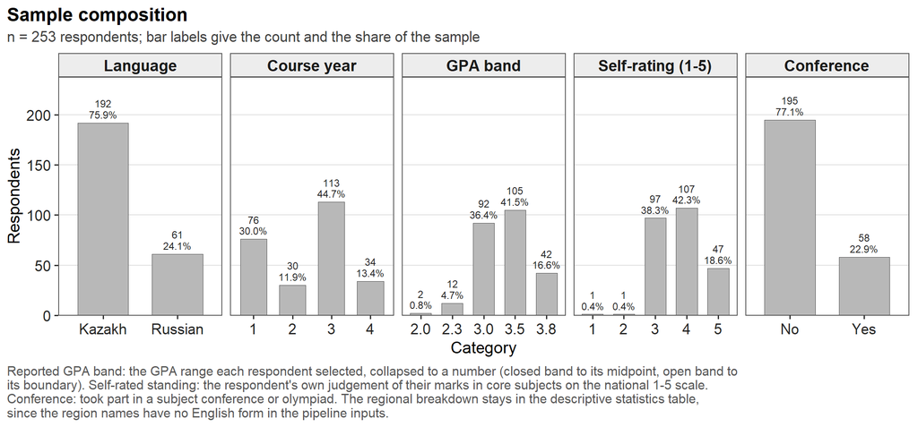

Состав выборки: язык анкеты, курс, самооценка успеваемости, участие в конференциях

Баллы по курсам

| Показатель | Курс | N | Mean (M) | SD | Median (Mdn) | Min | Max | Skewness | Kurtosis |
| --- | --- | --- | --- | --- | --- | --- | --- | --- | --- |
| Общий балл | 1 курс | 76 | 16.75 | 8.34 | 18.00 | 4.00 | 26.00 | -0.14 | -1.72 |
| Общий балл | 2 курс | 30 | 17.73 | 7.12 | 18.00 | 7.00 | 26.00 | -0.16 | -1.51 |
| Общий балл | 3 курс | 113 | 14.80 | 7.80 | 14.00 | 3.00 | 26.00 | 0.23 | -1.50 |
| Общий балл | 4 курс | 34 | 15.94 | 7.40 | 17.50 | 5.00 | 26.00 | -0.03 | -1.54 |
| S1: Интерпретация | 1 курс | 76 | 5.28 | 2.67 | 7.00 | 0.00 | 8.00 | -0.36 | -1.41 |
| S1: Интерпретация | 2 курс | 30 | 5.53 | 2.40 | 6.50 | 0.00 | 8.00 | -0.56 | -0.92 |
| S1: Интерпретация | 3 курс | 113 | 5.04 | 2.60 | 5.00 | 0.00 | 8.00 | -0.22 | -1.35 |
| S1: Интерпретация | 4 курс | 34 | 5.32 | 2.20 | 6.00 | 1.00 | 8.00 | -0.35 | -1.17 |
| S2: Анализ | 1 курс | 76 | 5.74 | 3.27 | 7.00 | 0.00 | 9.00 | -0.28 | -1.60 |
| S2: Анализ | 2 курс | 30 | 6.20 | 2.57 | 6.00 | 2.00 | 9.00 | -0.20 | -1.51 |
| S2: Анализ | 3 курс | 113 | 5.02 | 3.21 | 5.00 | 0.00 | 9.00 | 0.01 | -1.57 |
| S2: Анализ | 4 курс | 34 | 5.32 | 2.74 | 5.50 | 0.00 | 9.00 | -0.20 | -1.01 |
| S3: Оценка | 1 курс | 76 | 5.74 | 3.06 | 5.00 | 0.00 | 9.00 | -0.20 | -1.51 |
| S3: Оценка | 2 курс | 30 | 6.00 | 2.68 | 6.00 | 1.00 | 9.00 | -0.23 | -1.30 |
| S3: Оценка | 3 курс | 113 | 4.74 | 2.95 | 4.00 | 0.00 | 9.00 | 0.34 | -1.37 |
| S3: Оценка | 4 курс | 34 | 5.29 | 3.14 | 5.50 | 1.00 | 9.00 | -0.04 | -1.58 |
| Theta (Раш) | 1 курс | 76 | 0.21 | 2.10 | -0.17 | -2.70 | 3.09 | 0.20 | -1.57 |
| Theta (Раш) | 2 курс | 30 | 0.34 | 1.89 | -0.17 | -2.01 | 3.09 | 0.36 | -1.36 |
| Theta (Раш) | 3 курс | 113 | -0.34 | 1.89 | -0.84 | -3.00 | 3.09 | 0.68 | -0.90 |
| Theta (Раш) | 4 курс | 34 | -0.16 | 1.78 | -0.26 | -2.44 | 3.09 | 0.61 | -0.76 |

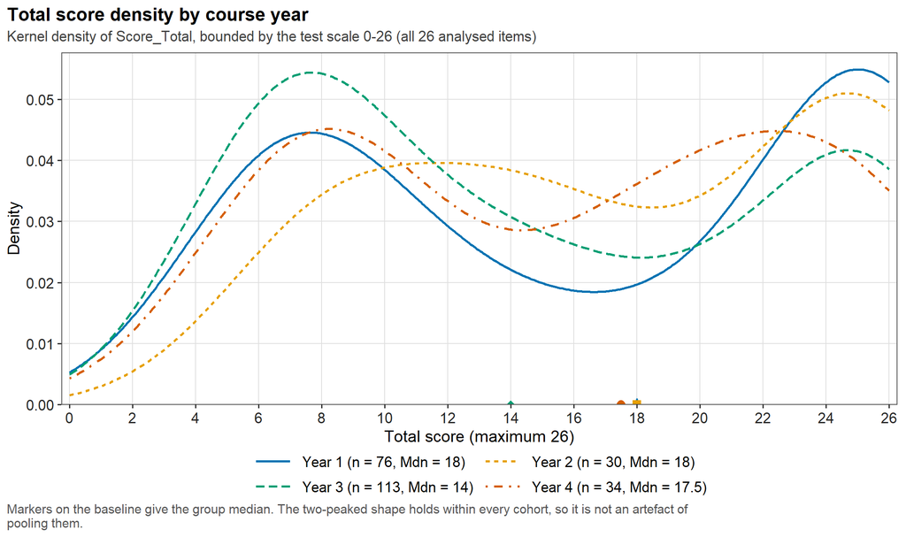

**Развёрнутые статистики**

```
====================================================================
  ОПИСАТЕЛЬНАЯ СТАТИСТИКА
  N = 253 участников
====================================================================

--------------------------------------------------------------------
  1. ЯЗЫК АНКЕТЫ
--------------------------------------------------------------------
   Категория                                N       %
   -----------------------------------  -----  ------
   kz                                     192   75.9%
   ru                                      61   24.1%
   ИТОГО                                  253  100.0%

--------------------------------------------------------------------
  2. КУРС ОБУЧЕНИЯ
--------------------------------------------------------------------
   Категория                                N       %
   -----------------------------------  -----  ------
   3                                      113   44.7%
   1                                       76   30.0%
   4                                       34   13.4%
   2                                       30   11.9%
   ИТОГО                                  253  100.0%

   N = 253  (пропущено: 0)
   M = 2.415  SD = 1.057  SE = 0.066
   Min = 1.0  P25 = 1.0  Mdn = 3.0  P75 = 3.0  Max = 4.0
   IQR = 2.0
   Skewness = -0.2
   Kurtosis (excess) = -1.296
   Shapiro-Wilk: W = 0.8197, p = 0.0

--------------------------------------------------------------------
  3. РЕГИОН
--------------------------------------------------------------------
   Категория                                N       %
   -----------------------------------  -----  ------
   Алматы                                  50   19.8%
   Абайская область                        46   18.2%
```

[output cut: 51 more lines]

```
   -----------------------------------  -----  ------
   0                                      195   77.1%
   1                                       58   22.9%
   ИТОГО                                  253  100.0%

--------------------------------------------------------------------
  7. СУММАРНЫЙ БАЛЛ (Score_Total)
--------------------------------------------------------------------
   N = 253  (пропущено: 0)
   M = 15.885  SD = 7.867  SE = 0.495
   Min = 3.0  P25 = 8.0  Mdn = 15.0  P75 = 24.0  Max = 26.0
   IQR = 16.0
   Skewness = 0.034
   Kurtosis (excess) = -1.606
   Shapiro-Wilk: W = 0.8713, p = 0.0
```

# 3 Бимодальность выборки

Распределение суммарного балла бимодально: коэффициент бимодальности `BC = 0.700` при ссылочном уровне `0.556`, тест провала Хартигана `D = 0.0870` (p < 0.0001). На полу (<= 8 баллов) находится 28.9 % выборки, на потолке (>= 24) — 30.4 %; конвенциональный порог, за которым инструмент считается не покрывающим край шкалы, — 15 % с каждой стороны.

**Оговорка.** Коэффициенты внутренней согласованности не являются свойством одних только пунктов: они растут с разбросом выборки. При таком распределении alpha и omega частично измеряют разделение групп респондентов, а не связность пунктов, поэтому читать их как доказательство однородности пунктов нельзя. Таблица чувствительности ниже показывает, насколько они падают при усечении крайних баллов.

Крайние паттерны и мера бимодальности

| N | N_perfect | N_zero | N_score_levels | Ceiling_cut | Floor_cut | Pct_ceiling | Pct_floor | Skewness | Kurtosis | BC | BC_ref | Dip | Dip_p | Bimodal |
| --- | --- | --- | --- | --- | --- | --- | --- | --- | --- | --- | --- | --- | --- | --- |
| 253 | 45 | 0 | 24 | 24 | 8 | 30.4 | 28.9 | 0.034 | -1.606 | 0.7002 | 0.5556 | 0.087 | 0 | TRUE |

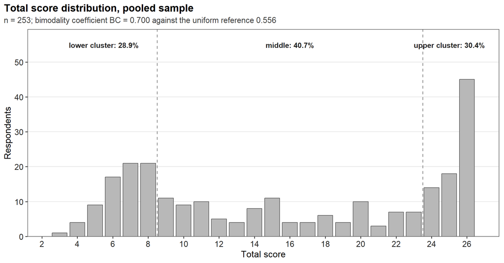

Распределение суммарного балла по всей выборке: полосы пола и потолка

**Частоты по каждому значению балла (27 строк)**

| Score | N | Pct | Cum_N | Cum_Pct |
| --- | --- | --- | --- | --- |
| 0 | 0 | 0.0 | 0 | 0.0 |
| 1 | 0 | 0.0 | 0 | 0.0 |
| 2 | 0 | 0.0 | 0 | 0.0 |
| 3 | 1 | 0.4 | 1 | 0.4 |
| 4 | 4 | 1.6 | 5 | 2.0 |
| 5 | 9 | 3.6 | 14 | 5.5 |
| 6 | 17 | 6.7 | 31 | 12.3 |
| 7 | 21 | 8.3 | 52 | 20.6 |
| 8 | 21 | 8.3 | 73 | 28.9 |
| 9 | 11 | 4.3 | 84 | 33.2 |
| 10 | 9 | 3.6 | 93 | 36.8 |
| 11 | 10 | 4.0 | 103 | 40.7 |
| 12 | 5 | 2.0 | 108 | 42.7 |
| 13 | 4 | 1.6 | 112 | 44.3 |
| 14 | 8 | 3.2 | 120 | 47.4 |
| 15 | 11 | 4.3 | 131 | 51.8 |
| 16 | 4 | 1.6 | 135 | 53.4 |
| 17 | 4 | 1.6 | 139 | 54.9 |
| 18 | 6 | 2.4 | 145 | 57.3 |
| 19 | 4 | 1.6 | 149 | 58.9 |
| 20 | 10 | 4.0 | 159 | 62.8 |
| 21 | 3 | 1.2 | 162 | 64.0 |
| 22 | 7 | 2.8 | 169 | 66.8 |
| 23 | 7 | 2.8 | 176 | 69.6 |
| 24 | 14 | 5.5 | 190 | 75.1 |
| 25 | 18 | 7.1 | 208 | 82.2 |
| 26 | 45 | 17.8 | 253 | 100.0 |

Надёжность и согласие CFA при усечении крайних баллов

| Sample | n | alpha | alpha_ord | omega_t | omega_h | H | WLE_rel | Conv_WLE | a_mean | Conv_2PL | Smoothed | CFA_1F_cfi | CFA_1F_rmsea | CFA_3F_cfi | CFA_3F_rmsea |
| --- | --- | --- | --- | --- | --- | --- | --- | --- | --- | --- | --- | --- | --- | --- | --- |
| FULL (all) | 253 | 0.938 | 0.970 | 0.978 | 0.922 | 0.440 | 0.841 | TRUE | 2.25 | TRUE | TRUE | 0.976 | 0.050 | 0.984 | 0.041 |
| NO-FLOOR (>8) | 180 | 0.908 | 0.953 | 0.964 | 0.785 | 0.349 | 0.744 | TRUE | 2.10 | TRUE | TRUE | 0.979 | 0.034 | 0.998 | 0.009 |
| NO-TAILS (9-25) | 135 | 0.858 | 0.916 | 0.936 | 0.618 | 0.244 | 0.798 | TRUE | 1.28 | TRUE | TRUE | 0.937 | 0.040 | 0.997 | 0.008 |
| MID only (9-23) | 103 | 0.742 | 0.830 | 0.839 | 0.385 | 0.132 | 0.711 | TRUE | 0.78 | TRUE | TRUE | 0.752 | 0.048 | 0.964 | 0.018 |

Валидность по известным группам на тех же подвыборках (p)

| Sample | n | Course_KW | Conference_t | Language_t | GPA_rho | GPA_p |
| --- | --- | --- | --- | --- | --- | --- |
| FULL (all) | 253 | 0.164 | 0.167 | 0.600 | 0.033 | 0.602 |
| NO-FLOOR (>8) | 180 | 0.069 | 0.076 | 0.623 | 0.041 | 0.583 |
| NO-TAILS (9-25) | 135 | 0.179 | 0.229 | 0.418 | -0.048 | 0.581 |
| MID only (9-23) | 103 | 0.641 | 0.521 | 0.094 | -0.139 | 0.162 |

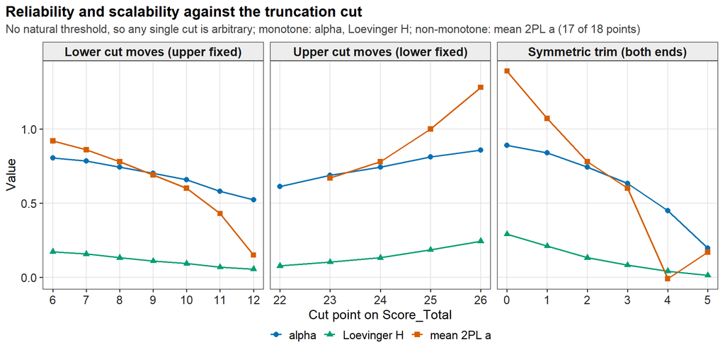

Градиент alpha, H и средней дискриминации по границе усечения

**Чувствительность к границам среза (18 строк)**

| Sweep | Cut | n | alpha | omega_h | H | a_mean | Conv_2PL |
| --- | --- | --- | --- | --- | --- | --- | --- |
| lower | 6 | 145 | 0.804 | 0.814 | 0.173 | 0.92 | TRUE |
| lower | 7 | 124 | 0.783 | 0.395 | 0.157 | 0.86 | TRUE |
| lower | 8 | 103 | 0.742 | 0.385 | 0.132 | 0.78 | TRUE |
| lower | 9 | 92 | 0.702 | 0.601 | 0.110 | 0.69 | TRUE |
| lower | 10 | 83 | 0.657 | 0.561 | 0.093 | 0.60 | TRUE |
| lower | 11 | 73 | 0.579 | 0.734 | 0.069 | 0.43 | TRUE |
| lower | 12 | 68 | 0.522 | 0.277 | 0.056 | 0.15 | TRUE |
| upper | 22 | 89 | 0.612 | 0.163 | 0.077 | NA | FALSE |
| upper | 23 | 96 | 0.687 | 0.619 | 0.103 | 0.67 | TRUE |
| upper | 24 | 103 | 0.742 | 0.385 | 0.132 | 0.78 | TRUE |
| upper | 25 | 117 | 0.811 | 0.483 | 0.185 | 1.00 | TRUE |
| upper | 26 | 135 | 0.858 | 0.618 | 0.244 | 1.28 | TRUE |
| symmetric | 0 | 177 | 0.889 | 0.606 | 0.291 | 1.39 | TRUE |
| symmetric | 1 | 138 | 0.838 | 0.538 | 0.211 | 1.07 | TRUE |
| symmetric | 2 | 103 | 0.742 | 0.385 | 0.132 | 0.78 | TRUE |
| symmetric | 3 | 85 | 0.633 | 0.640 | 0.083 | 0.60 | TRUE |
| symmetric | 4 | 69 | 0.450 | 0.569 | 0.042 | -0.01 | TRUE |
| symmetric | 5 | 56 | 0.198 | 0.272 | 0.014 | 0.17 | TRUE |

Естественного порога, на котором выборка распадалась бы на группы, нет: значение на любой ОДНОЙ границе — артефакт её выбора, а не измерение, а результатом является сам градиент. По измерению шага 2 (`Bimodality/cut_monotonicity.csv`): во всех трёх развёртках монотонны `alpha`, `H`; монотонность нарушена хотя бы в одной развёртке у `a_mean` (17 точек из 18). Названный числом охват неполон: точка развёртки, на которой рефит 2PL не сошёлся, снята вместе со своим значением (`Conv_2PL = FALSE` в таблице выше), поэтому вердикт о монотонности относится к ОЦЕНЁННЫМ точкам; установленная немонотонность от пропусков не зависит. Колонка `omega_h` в проверку монотонности не входит: она приведена как свидетельство нестабильности и интерпретации не подлежит.

**Развёрнутые статистики: бимодальность выборки**

```
====================================================================
  БИМОДАЛЬНОСТЬ ВЫБОРКИ -- N = 253, пунктов: 26
====================================================================

--------------------------------------------------------------------
  1. РАСПРЕДЕЛЕНИЕ SCORE_TOTAL
--------------------------------------------------------------------
  M = 15.89  SD = 7.87  Min = 3  Max = 26
  Skewness = 0.034  Kurtosis (excess) = -1.606

s
 3  4  5  6  7  8  9 10 11 12 13 14 15 16 17 18 19 20 21 22 23 24 25 26
 1  4  9 17 21 21 11  9 10  5  4  8 11  4  4  6  4 10  3  7  7 14 18 45

  потолок (>= 24): 77 (30.4%)
  полный балл (= 26): 45 (17.8%)
  пол (<= 8): 73 (28.9%)
  середина (9-23): 103 (40.7%), максимум наблюдений на один балл: 11
  различных значений балла: 24 на 253 респондентов

--------------------------------------------------------------------
  2. МЕРА БИМОДАЛЬНОСТИ
--------------------------------------------------------------------
  Коэффициент бимодальности BC = 0.7002 (ссылочный уровень 5/9 = 0.5556)
  Тест провала Хартигана: D = 0.08696, p < 0.0001 (ниже предела таблицы квантилей)
  Вывод по BC: распределение БИМОДАЛЬНО
  BC чувствителен к платикуртозу, поэтому тест Хартигана приведён рядом:
  он проверяет унимодальность напрямую, а не через моменты.

  Доли краёв против конвенционального порога 15 %: пол 28.9 %, потолок 30.4 %.

--------------------------------------------------------------------
  3. УРОВЕНЬ УГАДЫВАНИЯ (обоснование нижней границы)
--------------------------------------------------------------------
  Binom(26, 1/4): M = 6.5, SD = 2.21
    90% чистых угадывающих набирают <= 9
    95% чистых угадывающих набирают <= 10
    99% чистых угадывающих набирают <= 12
  Порог пола 8 консервативен: баллы выше него, но ниже 11,
  от угадывания статистически неотличимы и остаются в середине.
```

[output cut: 51 more lines]

```
 symmetric   1 138 0.838   0.538 0.211   1.07     TRUE
 symmetric   2 103 0.742   0.385 0.132   0.78     TRUE
 symmetric   3  85 0.633   0.640 0.083   0.60     TRUE
 symmetric   4  69 0.450   0.569 0.042  -0.01     TRUE
 symmetric   5  56 0.198   0.272 0.014   0.17     TRUE

  Монотонны во всех трёх развёртках: alpha, H.
  Немонотонны: a_mean -- монотонность нарушена не во всех развёртках.
  Охват неполон, вердикт относится к оценённым точкам (немонотонность от пропусков не зависит): a_mean -- 17 точек из 18.
  Естественного порога нет: значение на одной границе измерением не является.
  a_mean <= 0 (оценка 2PL вырождена, n мал): symmetric Cut=4 (n=69, a_mean=-0.01).
  2PL не сошлась, a_mean снят (оценкой не является): upper Cut=22 (n=89).
  omega_h скачет без закономерности: на этих объёмах он не интерпретируется.

====================================================================
```

# 4 Дистракторный анализ (CTT)

Скрининг пунктов классической теории тестов: доля выбора и точечно-бисериальная корреляция каждого варианта ответа. Тепловая карта — обзорный вид; полная таблица по всем вариантам ниже в раскрывающемся блоке.

KZ- и RU-формы — разные переводы с разными текстами вариантов, поэтому буквы раздаются внутри своей формы (`A` — верный вариант формы по ключу ответов, `B` в KZ и `B` в RU — разные дистракторы), а доли и корреляции считаются по выборке своей формы.

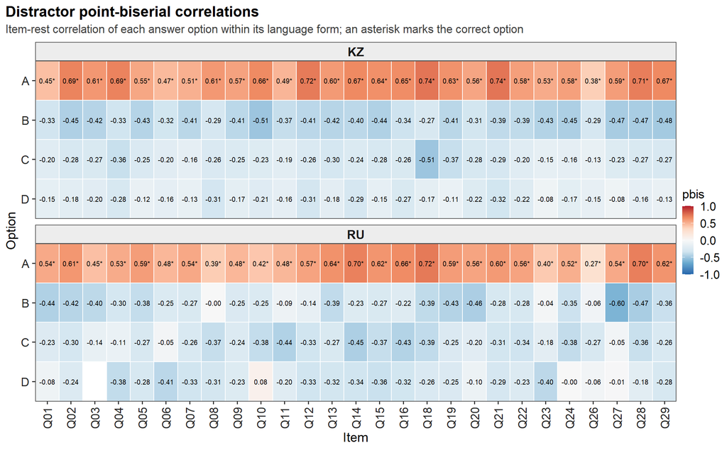

Тепловая карта точечно-бисериальных корреляций (item-rest) по вариантам ответа

**Точечно-бисериальные по вариантам (все пункты, отдельно по языковым формам) (216 строк)**

Item

Language

InCFA

Subscale

Option

IsCorrect

N

Pct

pbis

Q01

KZ

TRUE

S1

A

TRUE

145

75.5

0.450

Q01

KZ

TRUE

S1

B

FALSE

24

12.5

-0.329

Q01

KZ

TRUE

S1

C

FALSE

12

6.2

-0.201

Q01

KZ

TRUE

S1

D

FALSE

11

5.7

-0.155

Q01

RU

TRUE

S1

A

TRUE

41

67.2

0.539

Q01

RU

TRUE

S1

B

FALSE

10

16.4

-0.442

Q01

RU

TRUE

S1

C

FALSE

6

9.8

-0.233

Q01

RU

TRUE

S1

D

FALSE

4

6.6

-0.081

Q02

KZ

FALSE

A

TRUE

100

52.1

0.687

Q02

KZ

FALSE

B

FALSE

44

22.9

-0.447

Q02

KZ

FALSE

C

FALSE

33

17.2

-0.280

Q02

KZ

FALSE

D

FALSE

15

7.8

-0.185

Q02

RU

FALSE

A

TRUE

47

77.0

0.615

Q02

RU

FALSE

B

FALSE

6

9.8

-0.420

Q02

RU

FALSE

C

FALSE

5

8.2

-0.299

Q02

RU

FALSE

D

FALSE

3

4.9

-0.238

Q03

KZ

TRUE

S1

A

TRUE

122

63.5

0.612

Q03

KZ

TRUE

S1

B

FALSE

33

17.2

-0.424

Q03

KZ

TRUE

S1

C

FALSE

29

15.1

-0.267

Q03

KZ

TRUE

S1

D

FALSE

8

4.2

-0.196

Q03

RU

TRUE

S1

A

TRUE

47

77.0

0.447

Q03

RU

TRUE

S1

B

FALSE

10

16.4

-0.401

Q03

RU

TRUE

S1

C

FALSE

3

4.9

-0.135

Q03

RU

TRUE

S1

D

FALSE

1

1.6

NA

Q04

KZ

TRUE

S1

A

TRUE

110

57.3

0.689

Q04

KZ

TRUE

S1

B

FALSE

30

15.6

-0.330

Q04

KZ

TRUE

S1

C

FALSE

28

14.6

-0.362

Q04

KZ

TRUE

S1

D

FALSE

24

12.5

-0.282

Q04

RU

TRUE

S1

A

TRUE

38

62.3

0.533

Q04

RU

TRUE

S1

B

FALSE

9

14.8

-0.297

Q04

RU

TRUE

S1

C

FALSE

8

13.1

-0.114

Q04

RU

TRUE

S1

D

FALSE

6

9.8

-0.384

Q05

KZ

TRUE

S1

A

TRUE

141

73.4

0.550

Q05

KZ

TRUE

S1

B

FALSE

27

14.1

-0.426

Q05

KZ

TRUE

S1

C

FALSE

17

8.9

-0.253

Q05

KZ

TRUE

S1

D

FALSE

7

3.6

-0.122

Q05

RU

TRUE

S1

A

TRUE

48

78.7

0.588

Q05

RU

TRUE

S1

B

FALSE

7

11.5

-0.376

Q05

RU

TRUE

S1

C

FALSE

3

4.9

-0.274

Q05

RU

TRUE

S1

D

FALSE

3

4.9

-0.285

Q06

KZ

TRUE

S1

A

TRUE

123

64.1

0.471

Q06

KZ

TRUE

S1

B

FALSE

34

17.7

-0.321

Q06

KZ

TRUE

S1

C

FALSE

21

10.9

-0.198

Q06

KZ

TRUE

S1

D

FALSE

14

7.3

-0.161

Q06

RU

TRUE

S1

A

TRUE

36

59.0

0.482

Q06

RU

TRUE

S1

B

FALSE

10

16.4

-0.246

Q06

RU

TRUE

S1

C

FALSE

8

13.1

-0.047

Q06

RU

TRUE

S1

D

FALSE

7

11.5

-0.408

Q07

KZ

TRUE

S1

A

TRUE

123

64.1

0.510

Q07

KZ

TRUE

S1

B

FALSE

45

23.4

-0.410

Q07

KZ

TRUE

S1

C

FALSE

18

9.4

-0.163

Q07

KZ

TRUE

S1

D

FALSE

6

3.1

-0.134

Q07

RU

TRUE

S1

A

TRUE

44

72.1

0.544

Q07

RU

TRUE

S1

B

FALSE

8

13.1

-0.267

Q07

RU

TRUE

S1

C

FALSE

5

8.2

-0.262

Q07

RU

TRUE

S1

D

FALSE

4

6.6

-0.331

Q08

KZ

TRUE

S1

A

TRUE

102

53.1

0.608

Q08

KZ

TRUE

S1

B

FALSE

45

23.4

-0.292

Q08

KZ

TRUE

S1

C

FALSE

27

14.1

-0.259

Q08

KZ

TRUE

S1

D

FALSE

18

9.4

-0.309

Q08

RU

TRUE

S1

A

TRUE

32

52.5

0.393

Q08

RU

TRUE

S1

B

FALSE

18

29.5

-0.002

Q08

RU

TRUE

S1

C

FALSE

6

9.8

-0.370

Q08

RU

TRUE

S1

D

FALSE

5

8.2

-0.311

Q09

KZ

TRUE

S1

A

TRUE

126

65.6

0.569

Q09

KZ

TRUE

S1

B

FALSE

31

16.1

-0.406

Q09

KZ

TRUE

S1

C

FALSE

19

9.9

-0.248

Q09

KZ

TRUE

S1

D

FALSE

16

8.3

-0.169

Q09

RU

TRUE

S1

A

TRUE

39

63.9

0.482

Q09

RU

TRUE

S1

B

FALSE

11

18.0

-0.250

Q09

RU

TRUE

S1

C

FALSE

6

9.8

-0.242

Q09

RU

TRUE

S1

D

FALSE

5

8.2

-0.231

Q10

KZ

TRUE

S2

A

TRUE

127

66.1

0.662

Q10

KZ

TRUE

S2

B

FALSE

35

18.2

-0.506

Q10

KZ

TRUE

S2

C

FALSE

15

7.8

-0.228

Q10

KZ

TRUE

S2

D

FALSE

15

7.8

-0.213

Q10

RU

TRUE

S2

A

TRUE

35

57.4

0.418

Q10

RU

TRUE

S2

B

FALSE

13

21.3

-0.247

Q10

RU

TRUE

S2

C

FALSE

8

13.1

-0.376

Q10

RU

TRUE

S2

D

FALSE

5

8.2

0.078

Q11

KZ

TRUE

S2

A

TRUE

135

70.3

0.489

Q11

KZ

TRUE

S2

B

FALSE

37

19.3

-0.370

Q11

KZ

TRUE

S2

C

FALSE

11

5.7

-0.189

Q11

KZ

TRUE

S2

D

FALSE

9

4.7

-0.160

Q11

RU

TRUE

S2

A

TRUE

41

67.2

0.483

Q11

RU

TRUE

S2

B

FALSE

8

13.1

-0.091

Q11

RU

TRUE

S2

C

FALSE

7

11.5

-0.439

Q11

RU

TRUE

S2

D

FALSE

5

8.2

-0.205

Q12

KZ

TRUE

S2

A

TRUE

100

52.1

0.717

Q12

KZ

TRUE

S2

B

FALSE

37

19.3

-0.407

Q12

KZ

TRUE

S2

C

FALSE

29

15.1

-0.256

Q12

KZ

TRUE

S2

D

FALSE

26

13.5

-0.311

Q12

RU

TRUE

S2

A

TRUE

32

52.5

0.566

Q12

RU

TRUE

S2

B

FALSE

13

21.3

-0.145

Q12

RU

TRUE

S2

C

FALSE

9

14.8

-0.330

Q12

RU

TRUE

S2

D

FALSE

7

11.5

-0.333

Q13

KZ

TRUE

S2

A

TRUE

139

72.4

0.603

Q13

KZ

TRUE

S2

B

FALSE

30

15.6

-0.421

Q13

KZ

TRUE

S2

C

FALSE

17

8.9

-0.302

Q13

KZ

TRUE

S2

D

FALSE

6

3.1

-0.179

Q13

RU

TRUE

S2

A

TRUE

42

68.9

0.635

Q13

RU

TRUE

S2

B

FALSE

8

13.1

-0.388

Q13

RU

TRUE

S2

C

FALSE

7

11.5

-0.267

Q13

RU

TRUE

S2

D

FALSE

4

6.6

-0.316

Q14

KZ

TRUE

S2

A

TRUE

108

56.2

0.668

Q14

KZ

TRUE

S2

B

FALSE

45

23.4

-0.403

Q14

KZ

TRUE

S2

C

FALSE

22

11.5

-0.243

Q14

KZ

TRUE

S2

D

FALSE

17

8.9

-0.292

Q14

RU

TRUE

S2

A

TRUE

35

57.4

0.696

Q14

RU

TRUE

S2

B

FALSE

12

19.7

-0.231

Q14

RU

TRUE

S2

C

FALSE

8

13.1

-0.453

Q14

RU

TRUE

S2

D

FALSE

6

9.8

-0.335

Q15

KZ

TRUE

S2

A

TRUE

111

57.8

0.642

Q15

KZ

TRUE

S2

B

FALSE

42

21.9

-0.443

Q15

KZ

TRUE

S2

C

FALSE

22

11.5

-0.285

Q15

KZ

TRUE

S2

D

FALSE

17

8.9

-0.152

Q15

RU

TRUE

S2

A

TRUE

38

62.3

0.623

Q15

RU

TRUE

S2

B

FALSE

14

23.0

-0.266

Q15

RU

TRUE

S2

C

FALSE

5

8.2

-0.370

Q15

RU

TRUE

S2

D

FALSE

4

6.6

-0.357

Q16

KZ

TRUE

S2

A

TRUE

96

50.0

0.653

Q16

KZ

TRUE

S2

B

FALSE

40

20.8

-0.344

Q16

KZ

TRUE

S2

C

FALSE

31

16.1

-0.263

Q16

KZ

TRUE

S2

D

FALSE

25

13.0

-0.267

Q16

RU

TRUE

S2

A

TRUE

38

62.3

0.658

Q16

RU

TRUE

S2

B

FALSE

9

14.8

-0.220

Q16

RU

TRUE

S2

C

FALSE

7

11.5

-0.433

Q16

RU

TRUE

S2

D

FALSE

7

11.5

-0.323

Q18

KZ

TRUE

S2

A

TRUE

87

45.3

0.737

Q18

KZ

TRUE

S2

B

FALSE

55

28.6

-0.273

Q18

KZ

TRUE

S2

C

FALSE

42

21.9

-0.506

Q18

KZ

TRUE

S2

D

FALSE

8

4.2

-0.172

Q18

RU

TRUE

S2

A

TRUE

35

57.4

0.721

Q18

RU

TRUE

S2

B

FALSE

14

23.0

-0.389

Q18

RU

TRUE

S2

C

FALSE

7

11.5

-0.386

Q18

RU

TRUE

S2

D

FALSE

5

8.2

-0.255

Q19

KZ

TRUE

S2

A

TRUE

128

66.7

0.634

Q19

KZ

TRUE

S2

B

FALSE

29

15.1

-0.412

Q19

KZ

TRUE

S2

C

FALSE

28

14.6

-0.368

Q19

KZ

TRUE

S2

D

FALSE

7

3.6

-0.114

Q19

RU

TRUE

S2

A

TRUE

43

70.5

0.592

Q19

RU

TRUE

S2

B

FALSE

14

23.0

-0.430

Q19

RU

TRUE

S2

C

FALSE

2

3.3

-0.251

Q19

RU

TRUE

S2

D

FALSE

2

3.3

-0.251

Q20

KZ

TRUE

S3

A

TRUE

119

62.0

0.556

Q20

KZ

TRUE

S3

B

FALSE

35

18.2

-0.312

Q20

KZ

TRUE

S3

C

FALSE

27

14.1

-0.280

Q20

KZ

TRUE

S3

D

FALSE

11

5.7

-0.225

Q20

RU

TRUE

S3

A

TRUE

38

62.3

0.562

Q20

RU

TRUE

S3

B

FALSE

15

24.6

-0.457

Q20

RU

TRUE

S3

C

FALSE

6

9.8

-0.197

Q20

RU

TRUE

S3

D

FALSE

2

3.3

-0.097

Q21

KZ

TRUE

S3

A

TRUE

101

52.6

0.737

Q21

KZ

TRUE

S3

B

FALSE

38

19.8

-0.391

Q21

KZ

TRUE

S3

C

FALSE

28

14.6

-0.292

Q21

KZ

TRUE

S3

D

FALSE

25

13.0

-0.324

Q21

RU

TRUE

S3

A

TRUE

38

62.3

0.602

Q21

RU

TRUE

S3

B

FALSE

9

14.8

-0.278

Q21

RU

TRUE

S3

C

FALSE

7

11.5

-0.314

Q21

RU

TRUE

S3

D

FALSE

7

11.5

-0.292

Q22

KZ

TRUE

S3

A

TRUE

112

58.3

0.582

Q22

KZ

TRUE

S3

B

FALSE

42

21.9

-0.390

Q22

KZ

TRUE

S3

C

FALSE

21

10.9

-0.202

Q22

KZ

TRUE

S3

D

FALSE

17

8.9

-0.221

Q22

RU

TRUE

S3

A

TRUE

36

59.0

0.565

Q22

RU

TRUE

S3

B

FALSE

15

24.6

-0.281

Q22

RU

TRUE

S3

C

FALSE

5

8.2

-0.337

Q22

RU

TRUE

S3

D

FALSE

5

8.2

-0.235

Q23

KZ

TRUE

S3

A

TRUE

103

53.6

0.530

Q23

KZ

TRUE

S3

B

FALSE

59

30.7

-0.434

Q23

KZ

TRUE

S3

C

FALSE

26

13.5

-0.154

Q23

KZ

TRUE

S3

D

FALSE

4

2.1

-0.079

Q23

RU

TRUE

S3

A

TRUE

30

49.2

0.405

Q23

RU

TRUE

S3

B

FALSE

15

24.6

-0.040

Q23

RU

TRUE

S3

C

FALSE

10

16.4

-0.176

Q23

RU

TRUE

S3

D

FALSE

6

9.8

-0.402

Q24

KZ

TRUE

S3

A

TRUE

116

60.4

0.578

Q24

KZ

TRUE

S3

B

FALSE

48

25.0

-0.454

Q24

KZ

TRUE

S3

C

FALSE

17

8.9

-0.163

Q24

KZ

TRUE

S3

D

FALSE

11

5.7

-0.173

Q24

RU

TRUE

S3

A

TRUE

39

63.9

0.517

Q24

RU

TRUE

S3

B

FALSE

11

18.0

-0.347

Q24

RU

TRUE

S3

C

FALSE

6

9.8

-0.382

Q24

RU

TRUE

S3

D

FALSE

5

8.2

-0.004

Q26

KZ

TRUE

S3

A

TRUE

135

70.3

0.383

Q26

KZ

TRUE

S3

B

FALSE

32

16.7

-0.290

Q26

KZ

TRUE

S3

C

FALSE

16

8.3

-0.129

Q26

KZ

TRUE

S3

D

FALSE

9

4.7

-0.146

Q26

RU

TRUE

S3

A

TRUE

39

63.9

0.267

Q26

RU

TRUE

S3

B

FALSE

12

19.7

-0.065

Q26

RU

TRUE

S3

C

FALSE

8

13.1

-0.274

Q26

RU

TRUE

S3

D

FALSE

2

3.3

-0.056

Q27

KZ

TRUE

S3

A

TRUE

118

61.5

0.588

Q27

KZ

TRUE

S3

B

FALSE

40

20.8

-0.471

Q27

KZ

TRUE

S3

C

FALSE

31

16.1

-0.231

Q27

KZ

TRUE

S3

D

FALSE

3

1.6

-0.078

Q27

RU

TRUE

S3

A

TRUE

38

62.3

0.538

Q27

RU

TRUE

S3

B

FALSE

12

19.7

-0.604

Q27

RU

TRUE

S3

C

FALSE

8

13.1

-0.053

Q27

RU

TRUE

S3

D

FALSE

3

4.9

-0.012

Q28

KZ

TRUE

S3

A

TRUE

89

46.4

0.708

Q28

KZ

TRUE

S3

B

FALSE

62

32.3

-0.467

Q28

KZ

TRUE

S3

C

FALSE

29

15.1

-0.267

Q28

KZ

TRUE

S3

D

FALSE

12

6.2

-0.162

Q28

RU

TRUE

S3

A

TRUE

38

62.3

0.703

Q28

RU

TRUE

S3

B

FALSE

9

14.8

-0.466

Q28

RU

TRUE

S3

C

FALSE

8

13.1

-0.359

Q28

RU

TRUE

S3

D

FALSE

6

9.8

-0.183

Q29

KZ

TRUE

S3

A

TRUE

107

55.7

0.666

Q29

KZ

TRUE

S3

B

FALSE

44

22.9

-0.482

Q29

KZ

TRUE

S3

C

FALSE

28

14.6

-0.272

Q29

KZ

TRUE

S3

D

FALSE

13

6.8

-0.128

Q29

RU

TRUE

S3

A

TRUE

36

59.0

0.625

Q29

RU

TRUE

S3

B

FALSE

12

19.7

-0.358

Q29

RU

TRUE

S3

C

FALSE

8

13.1

-0.262

Q29

RU

TRUE

S3

D

FALSE

5

8.2

-0.278

**Развёрнутые статистики**

```
========================================================================
 АНАЛИЗ ДИСТРАКТОРОВ — ТКМ-Хим  n=253 | 27 пунктов
========================================================================

── КОДИРОВКА ВАРИАНТОВ (A = правильный, отмечен *) ───────────────────
   Буквы раздаются внутри своей языковой формы: B в KZ и B в RU — разные
   варианты. A — верный ответ формы по ключу ответов.

Q01 [S1]:
  [KZ]
    A *  Заң талаптарына сәйкестік пен ішкі өндірістік тәртіп арасындағы қайшылық.
    B    Басшыға адалдық пен ресми рәсімдер арасындағы жеке таңдау.
    C    Мемлекеттік қауіпсіздік стандарттарының жеткіліксіздігі.
    D    Компаниядағы сапаны бақылау жүйесінің жүйелік дағдарысы.
  [RU]
    A *  Конфликт между юридической допустимостью и внутренней производственной дисциплин
    B    Личностный выбор между лояльностью начальнику и формальными процедурами.
    C    Недостаточность государственных стандартов безопасности.
    D    Системный кризис контроля качества в компании.

Q02 [excl]:
  [KZ]
    A *  Тақырып дұрыс емес: жануарларда шектен тыс дозада тек корреляция ғана анықталған
    B    Зерттеу кофенің денсаулыққа қауіпті екенін дәлелдейді.
    C    Нәтижелердің маңызы жоқ, себебі егеуқұйрықтарға жасалған тәжірибелер адамдарға қ
    D    Қорытынды жасау үшін тәжірибені адамдарға қайталап жүргізу қажет.
  [RU]
    A *  Заголовок некорректен: найдена лишь корреляция при экстремальных дозах у животны
    B    Результаты не имеют ценности, так как опыты на крысах неприменимы к людям.
    C    Исследование доказывает опасность кофе для здоровья.
    D    Для выводов необходимо повторить эксперимент на людях.

Q03 [S1]:
  [KZ]
    A *  Жаңа әдістерді енгізіңіз, бірақ ескіні ойланбай жоққа шығармаңыз.
    B    Инновациялардың пайдасына классикалық әдістерге тыйым салу.
    C    Педагогтерді оқыту формаларын іздеуде креативті болуға шақыру.
    D    Педагог күрделі терминологияны меңгеруі қажет.
  [RU]
    A *  Внедряйте новое, но не отказывайтесь от старого бездумно.
```

[output cut: 957 more lines]

```

Q29:
        score.level
response lower middle upper
      *A     4     14    18
       B     8      4     0
       C     5      3     0
       D     4      1     0


 ========================================================================
 СВОДКА
 ========================================================================
 pbis правильных ответов (по пунктам x языковым формам, n=54):
   M=0.576  SD=0.101  min=0.267  max=0.737
```

# 5 Разведочный факторный анализ (EFA)

**Собственные значения (26 строк)**

| Factor | Eigenvalue | PA_line |
| --- | --- | --- |
| 1 | 10.347 | 1.644 |
| 2 | 1.747 | 1.548 |
| 3 | 1.356 | 1.463 |
| 4 | 0.972 | 1.395 |
| 5 | 0.903 | 1.349 |
| 6 | 0.838 | 1.294 |
| 7 | 0.817 | 1.243 |
| 8 | 0.718 | 1.197 |
| 9 | 0.678 | 1.152 |
| 10 | 0.664 | 1.112 |
| 11 | 0.643 | 1.057 |
| 12 | 0.623 | 1.014 |
| 13 | 0.602 | 0.978 |
| 14 | 0.561 | 0.947 |
| 15 | 0.526 | 0.911 |
| 16 | 0.489 | 0.875 |
| 17 | 0.451 | 0.843 |
| 18 | 0.421 | 0.804 |
| 19 | 0.414 | 0.771 |
| 20 | 0.391 | 0.740 |
| 21 | 0.366 | 0.701 |
| 22 | 0.356 | 0.666 |
| 23 | 0.317 | 0.631 |
| 24 | 0.317 | 0.602 |
| 25 | 0.279 | 0.559 |
| 26 | 0.201 | 0.504 |

Факторные нагрузки (ML, oblimin, 3 фактора)

| Item | ML2 | ML3 | ML1 |
| --- | --- | --- | --- |
| Q01 | 0.013 | 0.577 | 0.114 |
| Q03 | 0.293 | 0.272 | 0.431 |
| Q04 | 0.378 | 0.346 | 0.149 |
| Q05 | 0.495 | 0.028 | 0.284 |
| Q06 | -0.074 | 0.744 | -0.021 |
| Q07 | 0.396 | 0.087 | 0.333 |
| Q08 | 0.442 | 0.148 | 0.148 |
| Q09 | 0.011 | 0.665 | 0.205 |
| Q10 | 0.612 | -0.015 | 0.124 |
| Q11 | 0.137 | 0.526 | -0.113 |
| Q12 | 0.575 | 0.141 | 0.128 |
| Q13 | 0.590 | 0.002 | 0.227 |
| Q14 | 0.620 | 0.103 | 0.053 |
| Q15 | 0.608 | 0.024 | 0.183 |
| Q16 | 0.609 | 0.085 | 0.069 |
| Q18 | 0.714 | 0.086 | -0.002 |
| Q19 | 0.677 | -0.073 | 0.194 |
| Q20 | 0.237 | 0.538 | -0.236 |
| Q21 | 0.794 | -0.017 | -0.090 |
| Q22 | 0.602 | 0.052 | -0.113 |
| Q23 | 0.627 | -0.077 | -0.128 |
| Q24 | 0.700 | -0.074 | -0.135 |
| Q26 | 0.084 | 0.487 | -0.320 |
| Q27 | 0.670 | -0.070 | -0.007 |
| Q28 | 0.715 | 0.088 | -0.138 |
| Q29 | 0.711 | 0.038 | -0.157 |

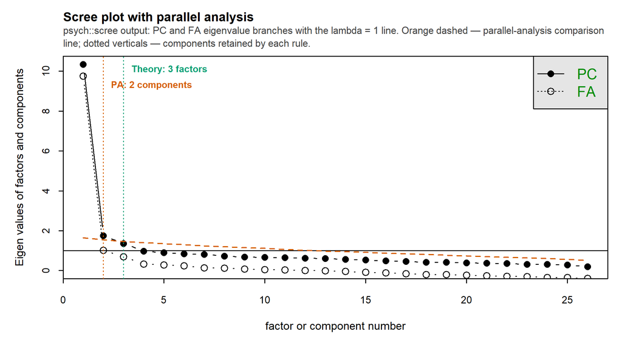

Собственные значения (scree) и параллельный анализ

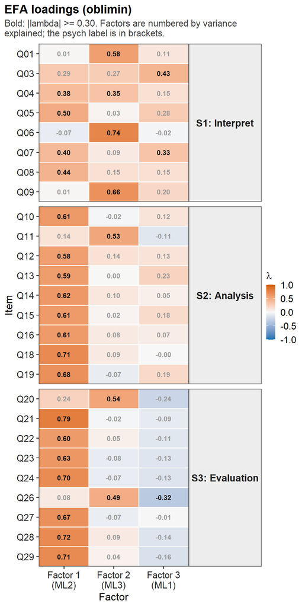

Тепловая карта факторных нагрузок (EFA)

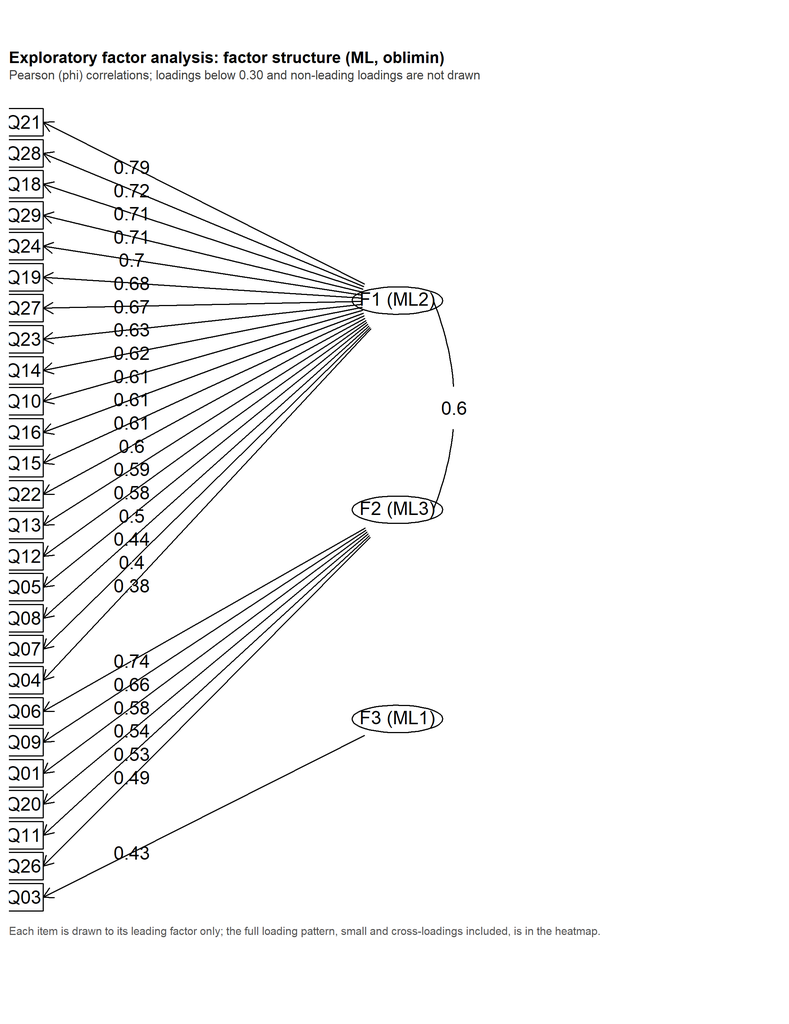

Структура факторов EFA (psych::fa.diagram, по ведущей нагрузке)

**Развёрнутые статистики**

```
=============================================================
  РАЗВЕДОЧНЫЙ ФАКТОРНЫЙ АНАЛИЗ (EFA) - n = 253
=============================================================

Прим.: корреляции — Пирсона (phi). Тетрахорическая матрица на этих данных не
положительно определена (ISSUES.md 1.1); после сглаживания почти вырождена,
поэтому KMO/RMSEA по ней были бы артефактами. phi занижает нагрузки (принятый
компромисс; структура подтверждена CFA/ESEM). Обоснование — DECISIONS.md D6.

KMO = 0.939

Bartlett: chi2(325) = 3029.93, p = 0.0000

Parallel analysis suggests that the number of factors =  3  and the number of components =  2
Рекомендуемое число факторов (параллельный анализ, FA-ветка): 3
Число компонент (PCA-ветка; ей соответствует линия PA на scree-графике): 2

Факторные нагрузки (oblimin, cut=.3):

Loadings:
    ML2    ML3    ML1
Q10  0.612
Q12  0.575
Q13  0.590
Q14  0.620
Q15  0.608
Q16  0.609
Q18  0.714
Q19  0.677
Q21  0.794
Q22  0.602
Q23  0.627
Q24  0.700
Q27  0.670
Q28  0.715
Q29  0.711
Q01         0.577
Q06         0.744
Q09         0.665
Q11         0.526
Q20         0.538
Q03                0.431
Q04  0.378  0.346
Q05  0.495
Q07  0.396         0.333
Q08  0.442
Q26         0.487 -0.320

                 ML2   ML3   ML1
SS loadings    7.403 2.436 0.909
Proportion Var 0.285 0.094 0.035
Cumulative Var 0.285 0.378 0.413

RMSEA = 0.045 | TLI = 0.939 | BIC = -1006.9
Корреляции факторов (Phi):
      ML2   ML3   ML1
ML2 1.000 0.604 0.194
ML3 0.604 1.000 0.124
ML1 0.194 0.124 1.000
```

# 6 Подтверждающий факторный анализ (CFA)

Сравниваются три модели: однофакторная (1F-CFA), 3-факторная ICM-CFA и бифакторная CFA. Модель названа своей природой, а не позицией в таблице: ярлыки 1F-CFA и 3F-ICM-CFA означают в разделе ESEM ниже те же две модели, что здесь.

Сравнение моделей CFA (масштабированные индексы согласия, WLSMV)

| Model | Chisq | df | p | CFI | TLI | RMSEA | CI90 | SRMR |
| --- | --- | --- | --- | --- | --- | --- | --- | --- |
| 1F-CFA (однофакторная) | 485.16 | 299 | 0 | 0.976 | 0.974 | 0.050 | [0.042;0.058] | 0.085 |
| 3F-ICM-CFA (3-факторная) | 423.90 | 296 | 0 | 0.984 | 0.982 | 0.041 | [0.032;0.050] | 0.077 |
| Бифакторная CFA | NA | NA | NA | NA | NA | NA | [NA;NA] | NA |

**Оговорка.** Бифакторная модель CFA не сошлась — оптимизатор не достиг сходимости, индексы согласия недоступны (`NA`). Ниже приведены результаты только для 1F-CFA и 3F-ICM-CFA. Бифакторная *2PL*-модель (раздел Надёжность) сошлась; неустойчива именно CFA-версия на текущем наборе пунктов.

Нагрузки 3-факторной ICM-CFA (стандартизованные Beta)

| Factor | Item | B | SE | z | p | Beta |
| --- | --- | --- | --- | --- | --- | --- |
| S1 | Q01 | 1.000 | 0.000 | NA | NA | 0.688 |
| S1 | Q03 | 1.172 | 0.102 | 11.458 | 0 | 0.806 |
| S1 | Q04 | 1.259 | 0.107 | 11.752 | 0 | 0.866 |
| S1 | Q05 | 1.197 | 0.111 | 10.807 | 0 | 0.823 |
| S1 | Q06 | 0.975 | 0.094 | 10.386 | 0 | 0.671 |
| S1 | Q07 | 1.063 | 0.112 | 9.456 | 0 | 0.731 |
| S1 | Q08 | 1.120 | 0.121 | 9.223 | 0 | 0.770 |
| S1 | Q09 | 1.109 | 0.095 | 11.721 | 0 | 0.762 |
| S2 | Q10 | 1.000 | 0.000 | NA | NA | 0.781 |
| S2 | Q11 | 0.846 | 0.076 | 11.122 | 0 | 0.661 |
| S2 | Q12 | 1.105 | 0.068 | 16.146 | 0 | 0.863 |
| S2 | Q13 | 1.060 | 0.063 | 16.921 | 0 | 0.828 |
| S2 | Q14 | 1.083 | 0.069 | 15.706 | 0 | 0.846 |
| S2 | Q15 | 1.043 | 0.066 | 15.724 | 0 | 0.815 |
| S2 | Q16 | 1.062 | 0.070 | 15.189 | 0 | 0.830 |
| S2 | Q18 | 1.185 | 0.071 | 16.668 | 0 | 0.926 |
| S2 | Q19 | 1.056 | 0.065 | 16.277 | 0 | 0.825 |
| S3 | Q20 | 1.000 | 0.000 | NA | NA | 0.743 |
| S3 | Q21 | 1.237 | 0.093 | 13.311 | 0 | 0.919 |
| S3 | Q22 | 1.028 | 0.086 | 11.890 | 0 | 0.764 |
| S3 | Q23 | 0.918 | 0.106 | 8.690 | 0 | 0.682 |
| S3 | Q24 | 1.022 | 0.093 | 11.023 | 0 | 0.759 |
| S3 | Q26 | 0.682 | 0.082 | 8.358 | 0 | 0.506 |
| S3 | Q27 | 1.036 | 0.093 | 11.187 | 0 | 0.770 |
| S3 | Q28 | 1.213 | 0.095 | 12.775 | 0 | 0.901 |
| S3 | Q29 | 1.145 | 0.093 | 12.254 | 0 | 0.851 |

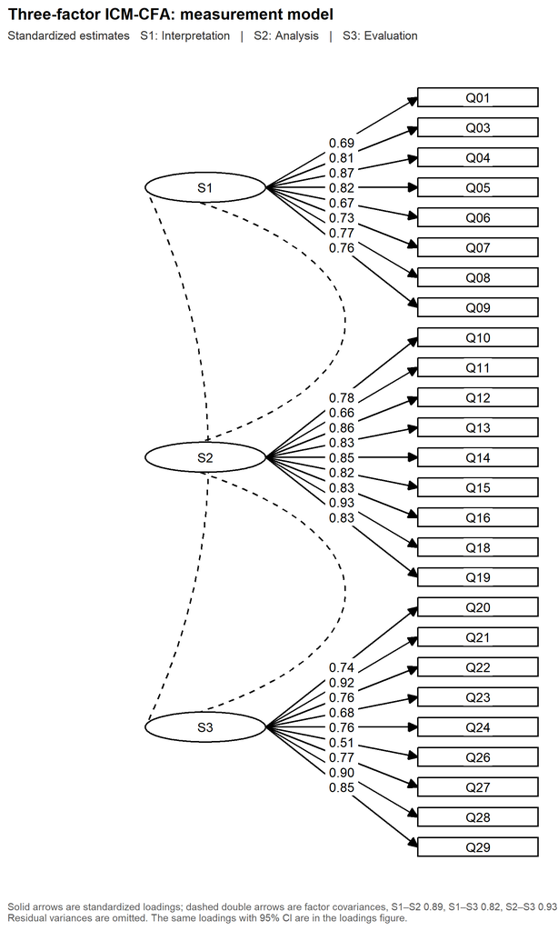

Схема измерительной модели 3-факторной ICM-CFA: какой пункт к какому фактору

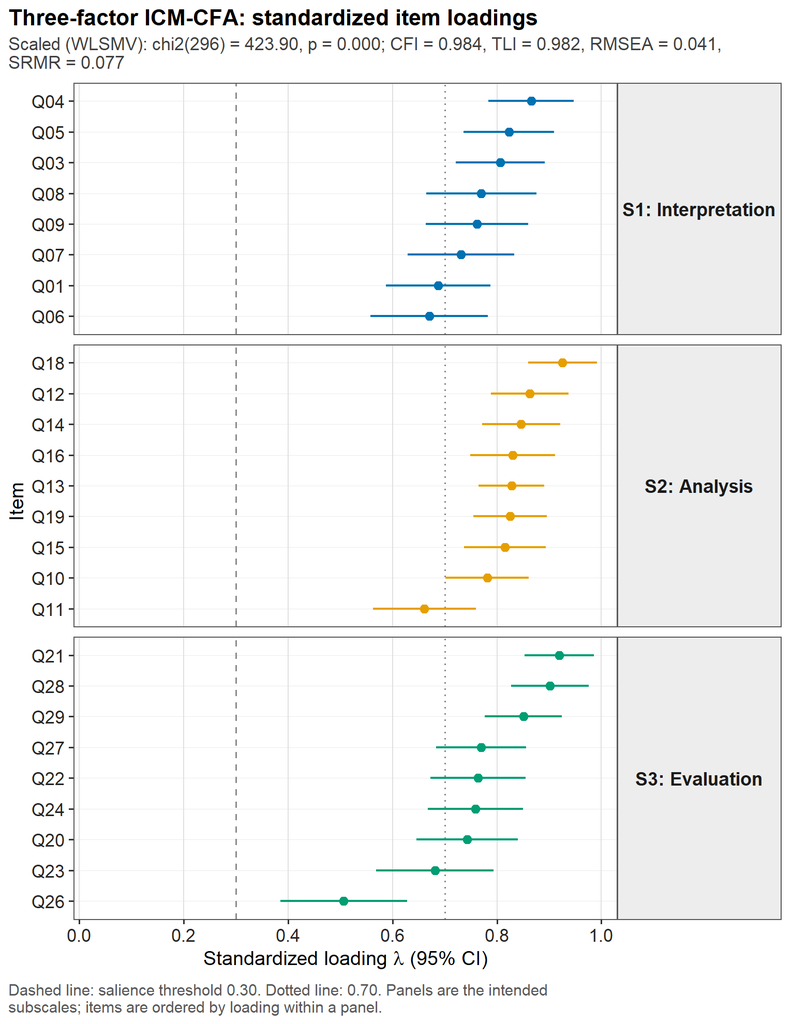

Стандартизованные нагрузки 3-факторной ICM-CFA с 95% ДИ; индексы согласия в подзаголовке

**Развёрнутые статистики**

```
=============================================================
  ПОДТВЕРЖДАЮЩИЙ ФАКТОРНЫЙ АНАЛИЗ (CFA) - n = 253
=============================================================

Прим.: индексы согласия — МАСШТАБИРОВАННЫЕ. estimator = "WLSMV" в lavaan — это
оценка DWLS с mean-and-variance-adjusted тестом (scaled.shifted), поэтому наивные
chisq/CFI/TLI/RMSEA из fitMeasures() посчитаны по нескорректированной статистике,
систематически оптимистичны и при этом тесте не интерпретируются, а наивный p не
определён вовсе. SRMR масштабирования не имеет и идёт как есть.

── ОДНОФАКТОРНАЯ CFA (1F) ──────────────────────────────────
  CFI = 0.976 | TLI = 0.974 | RMSEA = 0.050 [0.042; 0.058] | SRMR = 0.085

── 3-ФАКТОРНАЯ ICM-CFA (3F) ────────────────────────────────
  CFI = 0.984 | TLI = 0.982 | RMSEA = 0.041 [0.032; 0.050] | SRMR = 0.077

── БИФАКТОРНАЯ CFA ─────────────────────────────────────────
  !! МОДЕЛЬ НЕ СОШЛАСЬ (оптимизатор не достиг сходимости) — fit-индексы недоступны.

  Бифакторная модель на текущем наборе пунктов неустойчива; результаты ниже
  приводятся только для однофакторной и 3-факторной ICM-CFA.

── СРАВНЕНИЕ МОДЕЛЕЙ ───────────────────────────────────────
  1F-CFA (однофакторная)     CFI=0.976  TLI=0.974  RMSEA=0.050  SRMR=0.085
  3F-ICM-CFA (3-факторная)   CFI=0.984  TLI=0.982  RMSEA=0.041  SRMR=0.077

── НАГРУЗКИ 3-ФАКТОРНАЯ (λ) ───────────────────────────────
 Factor Item     B    SE      z  p  Beta
     S1  Q01 1.000 0.000     NA NA 0.688
     S1  Q03 1.172 0.102 11.458  0 0.806
     S1  Q04 1.259 0.107 11.752  0 0.866
     S1  Q05 1.197 0.111 10.807  0 0.823
     S1  Q06 0.975 0.094 10.386  0 0.671
     S1  Q07 1.063 0.112  9.456  0 0.731
     S1  Q08 1.120 0.121  9.223  0 0.770
     S1  Q09 1.109 0.095 11.721  0 0.762
     S2  Q10 1.000 0.000     NA NA 0.781
     S2  Q11 0.846 0.076 11.122  0 0.661
     S2  Q12 1.105 0.068 16.146  0 0.863
     S2  Q13 1.060 0.063 16.921  0 0.828
```

[output cut: 12 more lines]

```
     S3  Q28 1.213 0.095 12.775  0 0.901
     S3  Q29 1.145 0.093 12.254  0 0.851

── КОРРЕЛЯЦИИ МЕЖДУ ЛАТЕНТНЫМИ ФАКТОРАМИ ───────────────────
 lhs rhs   est std.all
  S1  S2 0.480   0.893
  S1  S3 0.420   0.822
  S2  S3 0.542   0.934

── НАГРУЗКИ БИФАКТОРНАЯ: пропущено (модель не сошлась) ────

── НАДЁЖНОСТЬ (α Кронбаха) ─────────────────────────────────
  S1: α = 0.825
  S2: α = 0.879
  S3: α = 0.855
```

# 7 ESEM: разведочная структурная модель

ESEM оценивает 3-факторную структуру в SEM-рамке (WLSMV, ordered — как CFA), но без запрета кросс-нагрузок: все пункты грузятся на все факторы, решение вращается (geomin, косоугольное). Это снимает главный дефект 3F-ICM-CFA. Раздел печатает три диагностики, и размерности касается только одна — прирост согласия 3F-ESEM над 1F-CFA. Корреляции факторов измеряют различимость факторов вращения, а доля пунктов на «своём» факторе — согласие априорной приписки с полученной вращением, а не размерность. Вердикт о размерности разделом не выносится: вопрос зафиксирован открытым в обе стороны (решения D3 и D12 в DECISIONS.md).

Согласие: 1F-CFA vs 3F-ICM-CFA vs 3F-ESEM (масштабированные индексы, WLSMV)

| Model | Chisq | df | p | CFI | TLI | RMSEA | CI90 | SRMR |
| --- | --- | --- | --- | --- | --- | --- | --- | --- |
| 1F-CFA (однофакторная) | 485.16 | 299 | 0.000 | 0.976 | 0.974 | 0.050 | [0.042;0.058] | 0.085 |
| 3F-ICM-CFA (3-факторная) | 423.90 | 296 | 0.000 | 0.984 | 0.982 | 0.041 | [0.032;0.050] | 0.077 |
| 3F-ESEM (geomin) | 257.93 | 250 | 0.352 | 0.999 | 0.999 | 0.011 | [0.000;0.028] | 0.048 |

Корреляции факторов ESEM (косоугольное решение)

| Pair | r |
| --- | --- |
| S1 ~ S3 | -0.151 |
| S1 ~ S2 | 0.668 |
| S3 ~ S2 | -0.210 |

**Нагрузки ESEM (стандартизованные, geomin) (26 строк)**

| Item | f1 (~S1) | f3 (~S2) | f2 (~S3) |
| --- | --- | --- | --- |
| Q01 | 0.737 | 0.005 | -0.142 |
| Q03 | 0.277 | 0.448 | -0.443 |
| Q04 | 0.420 | 0.456 | -0.126 |
| Q05 | -0.020 | 0.753 | -0.213 |
| Q06 | 0.946 | -0.164 | -0.010 |
| Q07 | 0.039 | 0.601 | -0.305 |
| Q08 | 0.193 | 0.548 | -0.142 |
| Q09 | 0.787 | 0.016 | -0.248 |
| Q10 | -0.034 | 0.801 | -0.054 |
| Q11 | 0.706 | 0.102 | 0.141 |
| Q12 | 0.185 | 0.701 | -0.090 |
| Q13 | -0.035 | 0.830 | -0.138 |
| Q14 | 0.149 | 0.733 | 0.006 |
| Q15 | 0.021 | 0.779 | -0.113 |
| Q16 | 0.123 | 0.729 | -0.032 |
| Q18 | 0.157 | 0.809 | 0.039 |
| Q19 | -0.112 | 0.901 | -0.074 |
| Q20 | 0.731 | 0.181 | 0.288 |
| Q21 | 0.029 | 0.907 | 0.159 |
| Q22 | 0.094 | 0.723 | 0.249 |
| Q23 | -0.058 | 0.766 | 0.260 |
| Q24 | -0.041 | 0.829 | 0.264 |
| Q26 | 0.710 | -0.021 | 0.383 |
| Q27 | -0.064 | 0.834 | 0.138 |
| Q28 | 0.199 | 0.768 | 0.220 |
| Q29 | 0.102 | 0.808 | 0.282 |

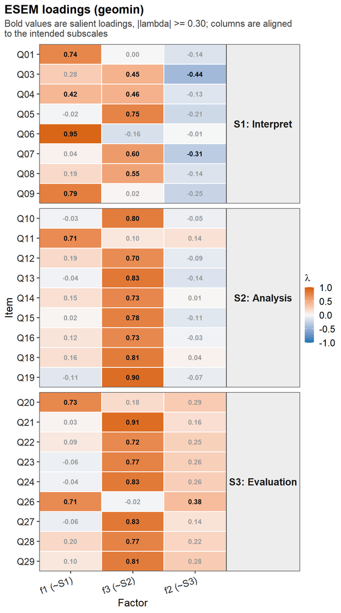

Тепловая карта нагрузок ESEM (geomin)

**Развёрнутые статистики**

```
======================================================================
  ESEM (geomin, WLSMV, ordered) - ТКМ-Хим | n = 253
======================================================================

СРАВНЕНИЕ МОДЕЛЕЙ (масштабированные индексы согласия, WLSMV)

                    Model  Chisq  df      p   CFI   TLI RMSEA          CI90
   1F-CFA (однофакторная) 485.16 299 0.0000 0.976 0.974 0.050 [0.042;0.058]
 3F-ICM-CFA (3-факторная) 423.90 296 0.0000 0.984 0.982 0.041 [0.032;0.050]
         3F-ESEM (geomin) 257.93 250 0.3516 0.999 0.999 0.011 [0.000;0.028]
  SRMR
 0.085
 0.077
 0.048

Читается так: если 3F-ESEM улучшает согласие относительно 1F-CFA лишь
незначительно, дополнительные факторы почти ничего не объясняют сверх
общего — довод в пользу одномерности. Заметный прирост CFI/TLI и падение
RMSEA/SRMR у 3F-ESEM — довод против.

======================================================================
НАГРУЗКИ ESEM (стандартизованные, geomin; |λ|>=.30 — простая структура)

 Item f1 (~S1) f3 (~S2) f2 (~S3)
  Q01    0.737    0.005   -0.142
  Q03    0.277    0.448   -0.443
  Q04    0.420    0.456   -0.126
  Q05   -0.020    0.753   -0.213
  Q06    0.946   -0.164   -0.010
  Q07    0.039    0.601   -0.305
  Q08    0.193    0.548   -0.142
  Q09    0.787    0.016   -0.248
  Q10   -0.034    0.801   -0.054
  Q11    0.706    0.102    0.141
  Q12    0.185    0.701   -0.090
  Q13   -0.035    0.830   -0.138
  Q14    0.149    0.733    0.006
  Q15    0.021    0.779   -0.113
  Q16    0.123    0.729   -0.032
  Q18    0.157    0.809    0.039
```

[output cut: 31 more lines]

```
      Мера согласия ДВУХ РАЗМЕТОК (объявленной и полученной вращением), а не
      размерности: низкая доля одинаково совместима с одним фактором, с тремя
      факторами не по объявленным границам и со слабым восстановлением вращения.

  Разрешающая способность выборки: max дезаттенюированная r субшкал = 0.913 (порог 0.90).
  Субшкалы на этой выборке НЕРАЗЛИЧИМЫ: с точностью до надёжности измеряют одно и
  то же. Диагностика (3) здесь не информативна ни в одну сторону — это ОГРАНИЧЕНИЕ
  выборки, а не находка. Та же проверка и та же причина (бимодальность балла,
  шаг 2) — B0 в analysis/subscale_assignment.md.
  Факторов, не доминирующих ни у одного пункта: 1 (f2). Привязка фактор ->
  субшкала полная по построению, поэтому такой фактор получает субшкалу по остатку
  и обнуляет её вклад в (3).

  Вердикт о размерности здесь НЕ выносится: вопрос зафиксирован открытым в обе
  стороны (DECISIONS.md D3), и ни одна из диагностик выше его не закрывает.
```

# 8 Надёжность и бифакторная модель

Индексы бифакторной модели рассчитаны по сошедшейся бифакторной 2PL. Коэффициенты альфа Кронбаха по субшкалам приведены в развёрнутых статистиках CFA выше.

Индексы бифакторной модели: omega_h, omega_total, ECV, PUC

| Index | Value |
| --- | --- |
| omega_h | 0.947 |
| omega_total | 0.980 |
| ECV | 0.870 |
| PUC | 0.692 |

Надёжность субшкал: omega_s (полная) и omega_hs (за вычетом общего фактора)

| Subscale | n_items | omega_s | omega_hs |
| --- | --- | --- | --- |
| S1 | 8 | 0.938 | 0.144 |
| S2 | 9 | 0.959 | 0.044 |
| S3 | 9 | 0.937 | 0.094 |

**Нагрузки бифакторной 2PL (общий фактор G и специфические S1–S3) (52 строк)**

| Factor | Item | Beta |
| --- | --- | --- |
| G | Q01 | 0.660 |
| G | Q03 | 0.791 |
| G | Q04 | 0.797 |
| G | Q05 | 0.861 |
| G | Q06 | 0.589 |
| G | Q07 | 0.731 |
| G | Q08 | 0.695 |
| G | Q09 | 0.683 |
| G | Q10 | 0.799 |
| G | Q11 | 0.667 |
| G | Q12 | 0.828 |
| G | Q13 | 0.905 |
| G | Q14 | 0.837 |
| G | Q15 | 0.807 |
| G | Q16 | 0.787 |
| G | Q18 | 0.874 |
| G | Q19 | 0.875 |
| G | Q20 | 0.715 |
| G | Q21 | 0.868 |
| G | Q22 | 0.746 |
| G | Q23 | 0.636 |
| G | Q24 | 0.746 |
| G | Q26 | 0.501 |
| G | Q27 | 0.768 |
| G | Q28 | 0.840 |
| G | Q29 | 0.811 |
| S1 | Q01 | 0.531 |
| S1 | Q03 | 0.280 |
| S1 | Q04 | 0.280 |
| S1 | Q05 | 0.066 |
| S1 | Q06 | 0.530 |
| S1 | Q07 | 0.116 |
| S1 | Q08 | 0.099 |
| S1 | Q09 | 0.575 |
| S2 | Q10 | 0.343 |
| S2 | Q11 | -0.059 |
| S2 | Q12 | 0.306 |
| S2 | Q13 | 0.082 |
| S2 | Q14 | 0.177 |
| S2 | Q15 | 0.314 |
| S2 | Q16 | 0.329 |
| S2 | Q18 | -0.004 |
| S2 | Q19 | 0.136 |
| S3 | Q20 | -0.010 |
| S3 | Q21 | 0.236 |
| S3 | Q22 | 0.297 |
| S3 | Q23 | 0.512 |
| S3 | Q24 | 0.267 |
| S3 | Q26 | 0.076 |
| S3 | Q27 | 0.239 |
| S3 | Q28 | 0.219 |
| S3 | Q29 | 0.377 |

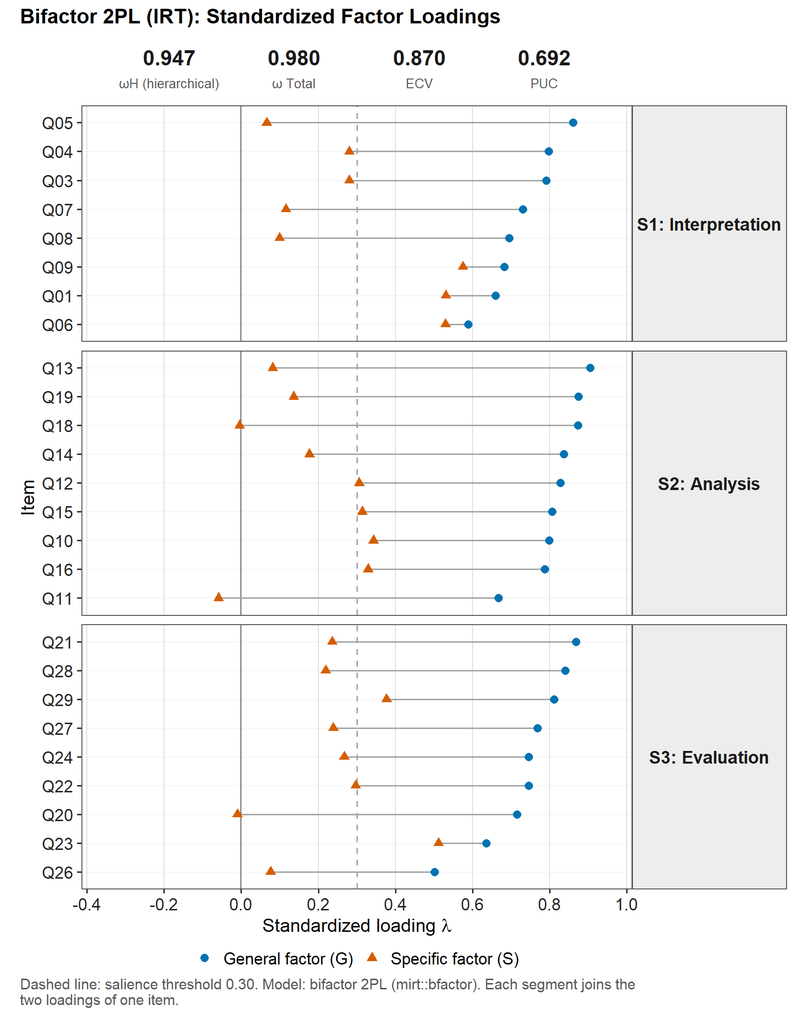

Нагрузки бифакторной 2PL: общий фактор G против специфических

**Оговорка.** Матрица корреляций оказалась не положительно определённой; при расчёте omega выполнено сглаживание (`cor.smooth`), что указывает на коллинеарность или экстремальные паттерны ответов.

**Оговорка.** Приведённые коэффициенты получены на выборке с бимодальным распределением суммарного балла (пол 28.9 %, потолок 30.4 %; раздел Бимодальность выборки). Надёжность — характеристика теста НА ДАННОЙ ВЫБОРКЕ, и она растёт с её разбросом: при усечении крайних баллов alpha и шкалируемость падают (таблица чувствительности того же раздела). Монотонность этого падения измерена, а не заявлена, и держится во всех трёх развёртках у `alpha`, `H`; `omega_h` в проверку не входит. Читать эти значения как однородность пунктов или как воспроизводимую характеристику инструмента нельзя.

**Развёрнутые статистики: расчёт omega**

```
======================================================================
  НАДЁЖНОСТЬ OMEGA - ТКМ-Хим

  Тетрахорическая матрица: min eigenvalue = -0.081705, положительно определена: нет
  Выполнено сглаживание (psych::cor.smooth) перед расчётом omega.

  omega_t = 0.978
  omega_h = 0.922
  alpha_ord = 0.970
  alpha_raw = 0.938
```

**Развёрнутые статистики: бифакторная CFA**

```
======================================================================
  БИФАКТОРНАЯ CFA - ТКМ-Хим | n = 253
======================================================================

СРАВНЕНИЕ МОДЕЛЕЙ (масштабированные индексы согласия, WLSMV)

                    Model  Chisq  df  p   CFI   TLI RMSEA          CI90  SRMR
   1F-CFA (однофакторная) 485.16 299  0 0.976 0.974 0.050 [0.042;0.058] 0.085
 3F-ICM-CFA (3-факторная) 423.90 296  0 0.984 0.982 0.041 [0.032;0.050] 0.077
          Бифакторная CFA     NA  NA NA    NA    NA    NA       [NA;NA]    NA

БИФАКТОРНЫЕ ИНДЕКСЫ:
  omega_h = NA
  ECV     = NA

БИФАКТОРНЫЕ НАГРУЗКИ: недоступны (модель не сошлась)
```

# 9 Модель Раша (1PL)

Сложность и статистики согласия пунктов (Rasch)

| Item | Outfit_MSQ | Infit_MSQ | Difficulty |
| --- | --- | --- | --- |
| Q01 | 0.879 | 1.092 | -1.858 |
| Q03 | 0.834 | 0.974 | -1.388 |
| Q04 | 0.841 | 0.918 | -0.825 |
| Q05 | 0.901 | 0.882 | -1.944 |
| Q06 | 1.157 | 1.210 | -1.120 |
| Q07 | 1.141 | 1.080 | -1.334 |
| Q08 | 1.357 | 1.163 | -0.443 |
| Q09 | 1.204 | 1.038 | -1.281 |
| Q10 | 0.780 | 0.973 | -1.200 |
| Q11 | 0.910 | 1.112 | -1.579 |
| Q12 | 0.759 | 0.898 | -0.388 |
| Q13 | 0.606 | 0.868 | -1.717 |
| Q14 | 0.724 | 0.889 | -0.690 |
| Q15 | 0.813 | 0.942 | -0.852 |
| Q16 | 0.979 | 0.967 | -0.443 |
| Q18 | 0.834 | 0.832 | -0.105 |
| Q19 | 0.678 | 0.870 | -1.442 |
| Q20 | 0.895 | 1.071 | -1.067 |
| Q21 | 0.693 | 0.835 | -0.581 |
| Q22 | 0.904 | 1.060 | -0.825 |
| Q23 | 1.344 | 1.250 | -0.416 |
| Q24 | 1.092 | 1.062 | -1.013 |
| Q26 | 1.345 | 1.355 | -1.524 |
| Q27 | 0.962 | 1.034 | -1.040 |
| Q28 | 0.779 | 0.861 | -0.247 |
| Q29 | 0.761 | 0.924 | -0.690 |

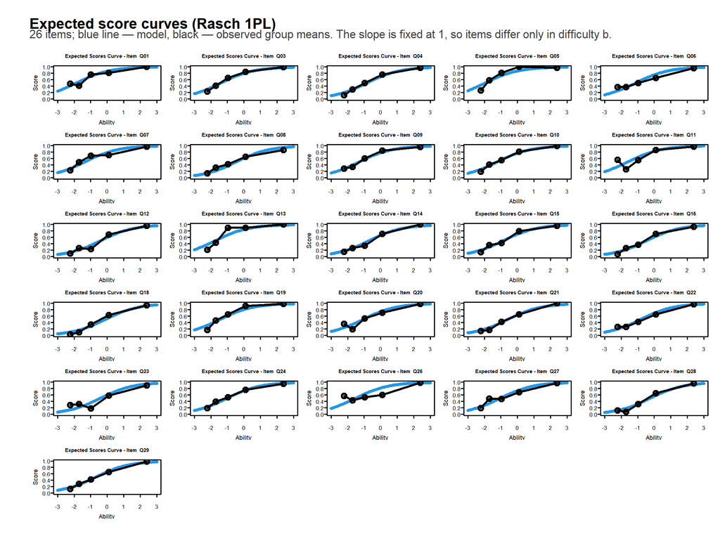

Характеристические кривые пунктов (Rasch)

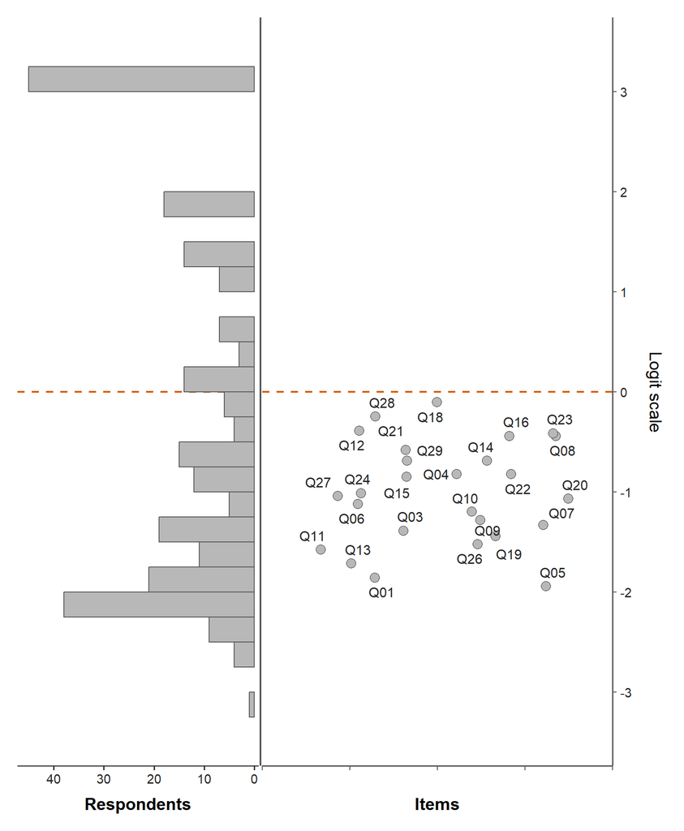

Карта Райта: пункты и способности

**Развёрнутые статистики**

```
====================================================================
  АНАЛИЗ ПО МОДЕЛИ РАША (1PL / Rasch)
====================================================================

  N респондентов : 253
  N пунктов      : 26

--------------------------------------------------------------------
  1. ТРУДНОСТЬ ПУНКТОВ (логиты) -- от трудных к лёгким
--------------------------------------------------------------------
  Item    b (logit)
  ------  ---------
  Q18        -0.105
  Q28        -0.247
  Q12        -0.388
  Q23        -0.416
  Q08        -0.443
  Q16        -0.443
  Q21        -0.581
  Q14        -0.690
  Q29        -0.690
  Q04        -0.825
  Q22        -0.825
  Q15        -0.852
  Q24        -1.013
  Q27        -1.040
  Q20        -1.067
  Q06        -1.120
  Q10        -1.200
  Q09        -1.281
  Q07        -1.334
  Q03        -1.388
  Q19        -1.442
  Q26        -1.524
  Q11        -1.579
  Q13        -1.717
  Q01        -1.858
  Q05        -1.944

  M = -1.000  SD = 0.510
```

[output cut: 38 more lines]

```
  AIC             : 6486.1
  BIC             : 6581.5

 --------------------------------------------------------------------
  4. ЛАТЕНТНЫЕ ОЦЕНКИ РАША (theta, WLE) -- описательная статистика
--------------------------------------------------------------------
  N = 253
  M = -0.072  SD = 1.949  SE = 0.123
  Min = -3.003  P25 = -1.826  Mdn = -0.682  P75 = 1.388  Max = 3.095
  IQR = 3.214
  Skewness = 0.468
  Kurtosis (excess) = -1.234
  Различных значений теты: 24 на 253 респондентов
  Наибольшая связка: 45 чел. на theta = 3.0945
  Shapiro-Wilk: W = 0.8807, p = 0.0000 (при точечной массе отклонение структурно)
```

# 10 2PL IRT

Двухпараметрическая модель (дискриминация `a`, трудность `b`) и её сравнение с Рашем.

Параметры 2PL (a, b, доля верных)

| Item | a | b | g | u | Subscale | p_value | b_1pl |
| --- | --- | --- | --- | --- | --- | --- | --- |
| Q01 | 1.646 | -0.955 | 0 | 1 | S1 | 0.735 | -1.859 |
| Q03 | 2.297 | -0.647 | 0 | 1 | S1 | 0.668 | -1.390 |
| Q04 | 2.410 | -0.392 | 0 | 1 | S1 | 0.585 | -0.827 |
| Q05 | 3.013 | -0.852 | 0 | 1 | S1 | 0.747 | -1.946 |
| Q06 | 1.366 | -0.581 | 0 | 1 | S1 | 0.628 | -1.122 |
| Q07 | 1.850 | -0.646 | 0 | 1 | S1 | 0.660 | -1.336 |
| Q08 | 1.642 | -0.191 | 0 | 1 | S1 | 0.530 | -0.446 |
| Q09 | 1.749 | -0.627 | 0 | 1 | S1 | 0.652 | -1.282 |
| Q10 | 2.431 | -0.560 | 0 | 1 | S2 | 0.640 | -1.202 |
| Q11 | 1.594 | -0.809 | 0 | 1 | S2 | 0.696 | -1.580 |
| Q12 | 2.623 | -0.203 | 0 | 1 | S2 | 0.522 | -0.390 |
| Q13 | 3.639 | -0.752 | 0 | 1 | S2 | 0.715 | -1.718 |
| Q14 | 2.726 | -0.339 | 0 | 1 | S2 | 0.565 | -0.692 |
| Q15 | 2.483 | -0.405 | 0 | 1 | S2 | 0.589 | -0.854 |
| Q16 | 2.291 | -0.215 | 0 | 1 | S2 | 0.530 | -0.446 |
| Q18 | 2.874 | -0.089 | 0 | 1 | S2 | 0.482 | -0.107 |
| Q19 | 3.224 | -0.653 | 0 | 1 | S2 | 0.676 | -1.444 |
| Q20 | 1.803 | -0.512 | 0 | 1 | S3 | 0.621 | -1.068 |
| Q21 | 3.054 | -0.302 | 0 | 1 | S3 | 0.549 | -0.583 |
| Q22 | 1.984 | -0.388 | 0 | 1 | S3 | 0.585 | -0.827 |
| Q23 | 1.488 | -0.171 | 0 | 1 | S3 | 0.526 | -0.418 |
| Q24 | 1.952 | -0.480 | 0 | 1 | S3 | 0.613 | -1.015 |
| Q26 | 1.062 | -0.946 | 0 | 1 | S3 | 0.688 | -1.526 |
| Q27 | 2.112 | -0.490 | 0 | 1 | S3 | 0.617 | -1.042 |
| Q28 | 2.660 | -0.143 | 0 | 1 | S3 | 0.502 | -0.250 |
| Q29 | 2.498 | -0.334 | 0 | 1 | S3 | 0.565 | -0.692 |

Сравнение 1PL и 2PL (информационные критерии)

| Model | AIC | SABIC | HQ | BIC | logLik | X2 | df | p |
| --- | --- | --- | --- | --- | --- | --- | --- | --- |
| mod_1pl | 6484.81 | 6494.62 | 6523.20 | 6580.22 | -3215.41 | NA | NA | NA |
| mod_2pl | 6451.56 | 6470.44 | 6525.48 | 6635.29 | -3173.78 | 83.26 | 25 | 0 |

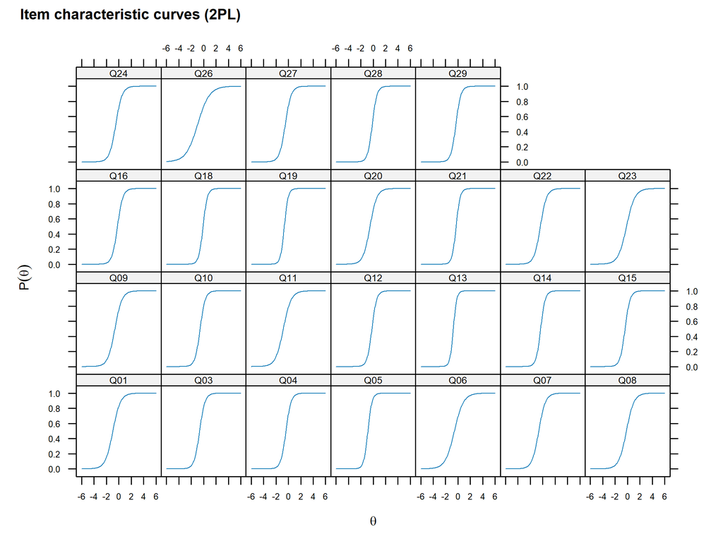

Характеристические кривые всех пунктов (2PL)

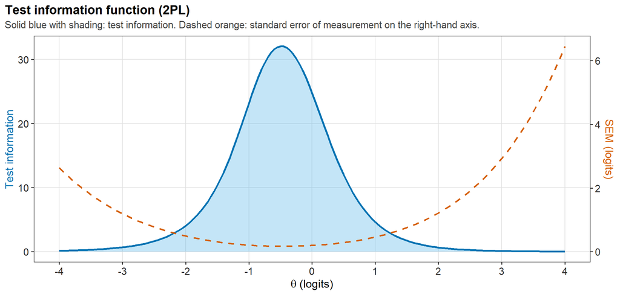

Информационная функция теста (2PL)

TIF/SEM в числах: максимум информации, значения при theta = 0 и диапазоны theta с приемлемой надёжностью

| Metric | Value |
| --- | --- |
| TI максимум | 32.074 |
| theta в максимуме TI | -0.500 |
| SEM минимум (в максимуме TI) | 0.177 |
| TI при theta = 0 | 24.773 |
| SEM при theta = 0 | 0.201 |
| rel = 1 - SEM^2 при theta = 0 | 0.960 |
| theta от (SEM <= 0.50, rel >= 0.75) | -2.000 |
| theta до (SEM <= 0.50, rel >= 0.75) | 1.050 |
| % EAP-тет в диапазоне rel >= 0.75 | 78.261 |
| theta от (SEM <= 0.32, rel >= 0.90) | -1.500 |
| theta до (SEM <= 0.32, rel >= 0.90) | 0.600 |
| % EAP-тет в диапазоне rel >= 0.90 | 69.960 |
| EAP-тета минимум | -1.338 |
| EAP-тета максимум | 1.505 |

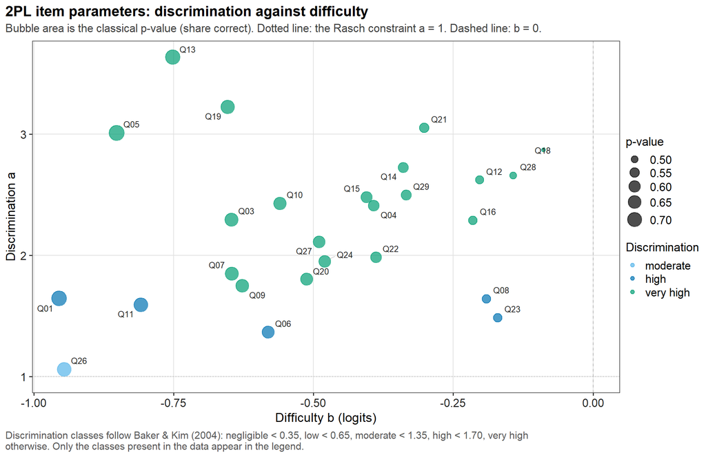

Дискриминация (a) против трудности (b) по пунктам

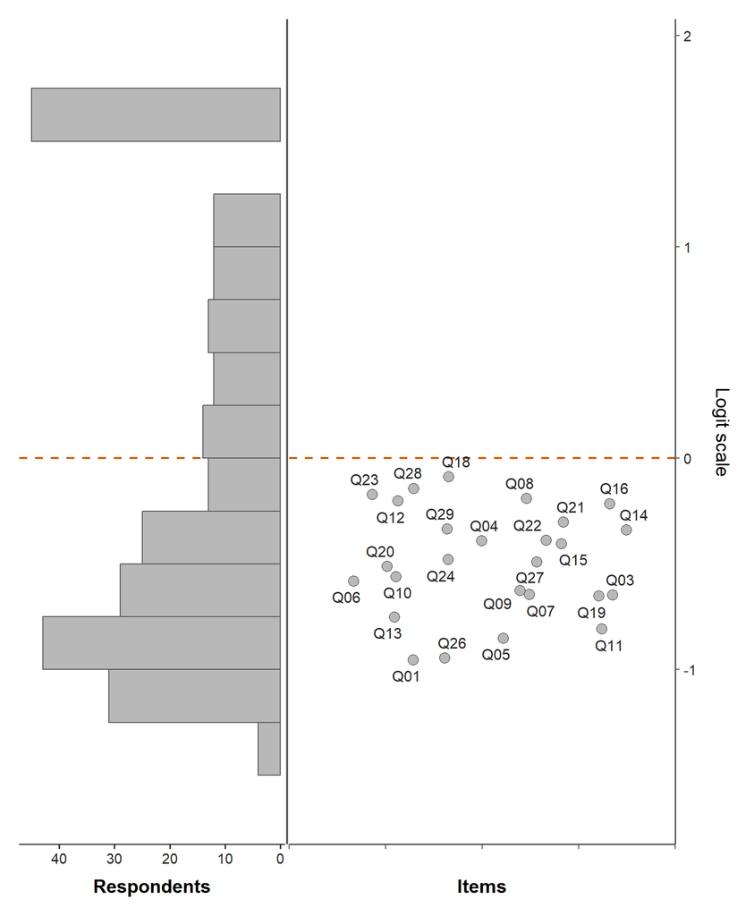

Карта Райта (2PL): способности против трудностей

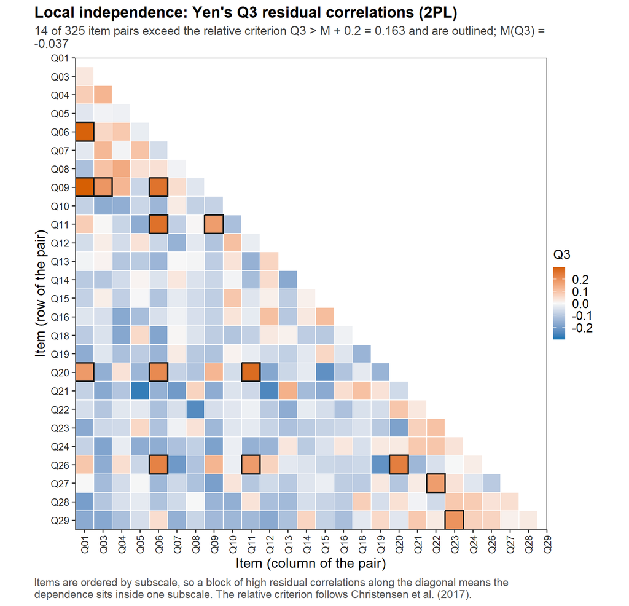

Локальная независимость: остаточные корреляции Yen’s Q3 по всем парам пунктов

**Развёрнутые статистики**

```
========================================================================
 2PL IRT-МОДЕЛЬ — ТКМ-Хим  n=253 | пунктов=26
========================================================================

── СРАВНЕНИЕ МОДЕЛЕЙ: 1PL vs 2PL (LRT) ──────────────────────────────

             AIC    SABIC       HQ      BIC    logLik     X2 df p
mod_1pl 6484.815 6494.622 6523.198 6580.217 -3215.407
mod_2pl 6451.558 6470.445 6525.481 6635.294 -3173.779 83.257 25 0

Абсолютный фит (M2*):
 1PL: M2=850.96 df=324 p=0.0000 RMSEA=0.080[0.074;0.087] TLI=0.954 CFI=0.954
 2PL: M2=681.19 df=299 p=0.0000 RMSEA=0.071[0.064;0.078] TLI=0.964 CFI=0.967


── ПАРАМЕТРЫ 2PL ─────────────────────────────────────────────────────

 Item   Sub    p-val a(disc) b(diff)   b_1pl
---------------------------------------------
 Q01    S1     0.735   1.646  -0.955  -1.859
 Q03    S1     0.668   2.297  -0.647  -1.390
 Q04    S1     0.585   2.410  -0.392  -0.827
 Q05    S1     0.747   3.013  -0.852  -1.946
 Q06    S1     0.628   1.366  -0.581  -1.122
 Q07    S1     0.660   1.850  -0.646  -1.336
 Q08    S1     0.530   1.642  -0.191  -0.446
 Q09    S1     0.652   1.749  -0.627  -1.282
 Q10    S2     0.640   2.431  -0.560  -1.202
 Q11    S2     0.696   1.594  -0.809  -1.580
 Q12    S2     0.522   2.623  -0.203  -0.390
 Q13    S2     0.715   3.639  -0.752  -1.718
 Q14    S2     0.565   2.726  -0.339  -0.692
 Q15    S2     0.589   2.483  -0.405  -0.854
 Q16    S2     0.530   2.291  -0.215  -0.446
 Q18    S2     0.482   2.874  -0.089  -0.107
 Q19    S2     0.676   3.224  -0.653  -1.444
 Q20    S3     0.621   1.803  -0.512  -1.068
 Q21    S3     0.549   3.054  -0.302  -0.583
 Q22    S3     0.585   1.984  -0.388  -0.827
 Q23    S3     0.526   1.488  -0.171  -0.418
```

[output cut: 95 more lines]

```
  Q13    S2       0.905     0.082    0.826
  Q14    S2       0.837     0.177    0.732
  Q15    S2       0.807     0.314    0.750
  Q16    S2       0.787     0.329    0.728
  Q18    S2       0.874    -0.004    0.763
  Q19    S2       0.875     0.136    0.784
  Q20    S3       0.715    -0.010    0.512
  Q21    S3       0.868     0.236    0.810
  Q22    S3       0.746     0.297    0.644
  Q23    S3       0.636     0.512    0.666
  Q24    S3       0.746     0.267    0.628
  Q26    S3       0.501     0.076    0.257
  Q27    S3       0.768     0.239    0.647
  Q28    S3       0.840     0.219    0.753
  Q29    S3       0.811     0.377    0.800
```

# 11 DIF: языковое смещение (kz vs ru)

Mantel-Haenszel DIF (skorr. p, lnOR, флаг)

| Item | Subscale | MH_chi2 | p_adj | lnOR | ETS_delta | ETS | SE | CI_low | CI_high | ETS_2 | DIF_flag |
| --- | --- | --- | --- | --- | --- | --- | --- | --- | --- | --- | --- |
| Q01 | S1 | 2.270 | 0.602 | -0.747 | 1.755 | C | 1.032 | -0.266 | 3.777 | A | - |
| Q03 | S1 | 3.062 | 0.602 | 0.717 | -1.686 | C | 0.970 | -3.587 | 0.215 | A | - |
| Q04 | S1 | 0.592 | 0.996 | 0.424 | -0.998 | A | 1.019 | -2.995 | 1.000 | A | - |
| Q05 | S1 | 0.022 | 0.996 | 0.044 | -0.104 | A | 1.140 | -2.338 | 2.130 | A | - |
| Q06 | S1 | 0.092 | 0.996 | -0.190 | 0.446 | A | 0.901 | -1.319 | 2.211 | A | - |
| Q07 | S1 | 0.585 | 0.996 | 0.404 | -0.950 | A | 0.977 | -2.865 | 0.965 | A | - |
| Q08 | S1 | 0.161 | 0.996 | -0.239 | 0.562 | A | 0.930 | -1.260 | 2.385 | A | - |
| Q09 | S1 | 0.433 | 0.996 | -0.322 | 0.757 | A | 0.920 | -1.045 | 2.559 | A | - |
| Q10 | S2 | 2.347 | 0.602 | -0.634 | 1.490 | B | 0.946 | -0.365 | 3.345 | A | - |
| Q11 | S2 | 0.634 | 0.996 | -0.398 | 0.935 | A | 0.950 | -0.927 | 2.797 | A | - |
| Q12 | S2 | 0.000 | 0.996 | 0.094 | -0.220 | A | 1.028 | -2.235 | 1.795 | A | - |
| Q13 | S2 | 2.259 | 0.602 | -0.813 | 1.910 | C | 1.140 | -0.323 | 4.144 | A | - |
| Q14 | S2 | 0.003 | 0.996 | -0.073 | 0.171 | A | 1.048 | -1.883 | 2.224 | A | - |
| Q15 | S2 | 0.129 | 0.996 | 0.239 | -0.563 | A | 0.975 | -2.473 | 1.348 | A | - |
| Q16 | S2 | 0.988 | 0.996 | 0.500 | -1.174 | B | 0.987 | -3.109 | 0.760 | A | - |
| Q18 | S2 | 2.190 | 0.602 | 0.831 | -1.954 | C | 1.123 | -4.155 | 0.247 | A | - |
| Q19 | S2 | 0.013 | 0.996 | -0.050 | 0.118 | A | 1.045 | -1.930 | 2.165 | A | - |
| Q20 | S3 | 0.005 | 0.996 | -0.056 | 0.132 | A | 0.962 | -1.754 | 2.018 | A | - |
| Q21 | S3 | 1.323 | 0.929 | 0.540 | -1.270 | B | 0.989 | -3.208 | 0.668 | A | - |
| Q22 | S3 | 0.103 | 0.996 | 0.237 | -0.558 | A | 0.994 | -2.506 | 1.391 | A | - |
| Q23 | S3 | 0.129 | 0.996 | -0.204 | 0.479 | A | 0.881 | -1.248 | 2.206 | A | - |
| Q24 | S3 | 0.001 | 0.996 | 0.087 | -0.205 | A | 0.926 | -2.020 | 1.610 | A | - |
| Q26 | S3 | 0.053 | 0.996 | -0.153 | 0.360 | A | 0.866 | -1.338 | 2.058 | A | - |
| Q27 | S3 | 0.003 | 0.996 | -0.104 | 0.243 | A | 0.945 | -1.610 | 2.097 | A | - |
| Q28 | S3 | 4.633 | 0.602 | 1.082 | -2.542 | C | 1.064 | -4.628 | -0.455 | A | - |
| Q29 | S3 | 0.028 | 0.996 | 0.156 | -0.367 | A | 0.969 | -2.267 | 1.533 | A | - |

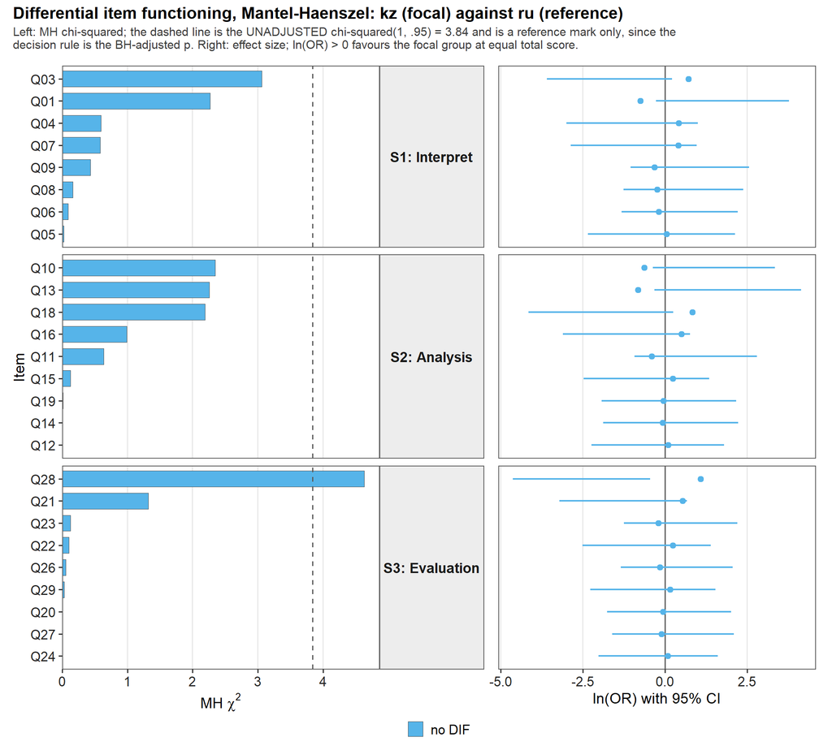

DIF по Мантелю-Хензелю (kz vs ru): статистика MH chi2 слева, величина эффекта lnOR с 95% ДИ справа

**Развёрнутые статистики**

```
======================================================================
  АНАЛИЗ DIF - язык (ru vs. kz)
  n(ru)=61 n(kz)=192 пунктов=26
======================================================================

MANTEL-HAENSZEL (поправка BH)

 Item Subscale MH_chi2  p_adj   lnOR ETS_delta ETS    SE CI_low CI_high ETS_2
  Q01       S1   2.270 0.6018 -0.747     1.755   C 1.032 -0.266   3.777     A
  Q03       S1   3.062 0.6018  0.717    -1.686   C 0.970 -3.587   0.215     A
  Q04       S1   0.592 0.9955  0.424    -0.998   A 1.019 -2.995   1.000     A
  Q05       S1   0.022 0.9955  0.044    -0.104   A 1.140 -2.338   2.130     A
  Q06       S1   0.092 0.9955 -0.190     0.446   A 0.901 -1.319   2.211     A
  Q07       S1   0.585 0.9955  0.404    -0.950   A 0.977 -2.865   0.965     A
  Q08       S1   0.161 0.9955 -0.239     0.562   A 0.930 -1.260   2.385     A
  Q09       S1   0.433 0.9955 -0.322     0.757   A 0.920 -1.045   2.559     A
  Q10       S2   2.347 0.6018 -0.634     1.490   B 0.946 -0.365   3.345     A
  Q11       S2   0.634 0.9955 -0.398     0.935   A 0.950 -0.927   2.797     A
  Q12       S2   0.000 0.9955  0.094    -0.220   A 1.028 -2.235   1.795     A
  Q13       S2   2.259 0.6018 -0.813     1.910   C 1.140 -0.323   4.144     A
  Q14       S2   0.003 0.9955 -0.073     0.171   A 1.048 -1.883   2.224     A
  Q15       S2   0.129 0.9955  0.239    -0.563   A 0.975 -2.473   1.348     A
  Q16       S2   0.988 0.9955  0.500    -1.174   B 0.987 -3.109   0.760     A
  Q18       S2   2.190 0.6018  0.831    -1.954   C 1.123 -4.155   0.247     A
  Q19       S2   0.013 0.9955 -0.050     0.118   A 1.045 -1.930   2.165     A
  Q20       S3   0.005 0.9955 -0.056     0.132   A 0.962 -1.754   2.018     A
  Q21       S3   1.323 0.9286  0.540    -1.270   B 0.989 -3.208   0.668     A
  Q22       S3   0.103 0.9955  0.237    -0.558   A 0.994 -2.506   1.391     A
  Q23       S3   0.129 0.9955 -0.204     0.479   A 0.881 -1.248   2.206     A
  Q24       S3   0.001 0.9955  0.087    -0.205   A 0.926 -2.020   1.610     A
  Q26       S3   0.053 0.9955 -0.153     0.360   A 0.866 -1.338   2.058     A
  Q27       S3   0.003 0.9955 -0.104     0.243   A 0.945 -1.610   2.097     A
  Q28       S3   4.633 0.6018  1.082    -2.542   C 1.064 -4.628  -0.455     A
  Q29       S3   0.028 0.9955  0.156    -0.367   A 0.969 -2.267   1.533     A
 DIF_flag
        -
        -
        -
        -
        -
```

[output cut: 12 more lines]

```
        -
        -
        -
        -
        -
        -
        -
        -
        -

Пунктов с DIF (MH, alpha=.05, BH): 0 из 26
ETS-классификация величины (|Delta|): A=18, B=3, C=5
ETS двойная классификация ETS_2 (Zwick 2012; знач. p_adj + односторонняя граница |D-DIF| > 1): A=26, B=0, C=0
DIF по логистической регрессии (alpha=.05, BH): 1 из 26
DIF по chi2 Лорда (1PL, alpha=.05, BH): 0 из 26
```

# 12 Валидность по известным группам (ANOVA)

Проверка различий в сырых баллах (общий и субшкалы S1-S3) по курсу, участию в конференциях, языку обучения, GPA и региону. WLE-тета шага Раша зависимой переменной не является: при полных данных она — строго возрастающая функция общего балла с вырожденной структурой связок, поэтому из раздела исключена (обоснование — решение D9 в DECISIONS.md).

**Оговорка.** Ни одно омнибусное групповое сравнение не достигло значимости (все p >= 0.05). Полный набор статистик — в блоке ниже.

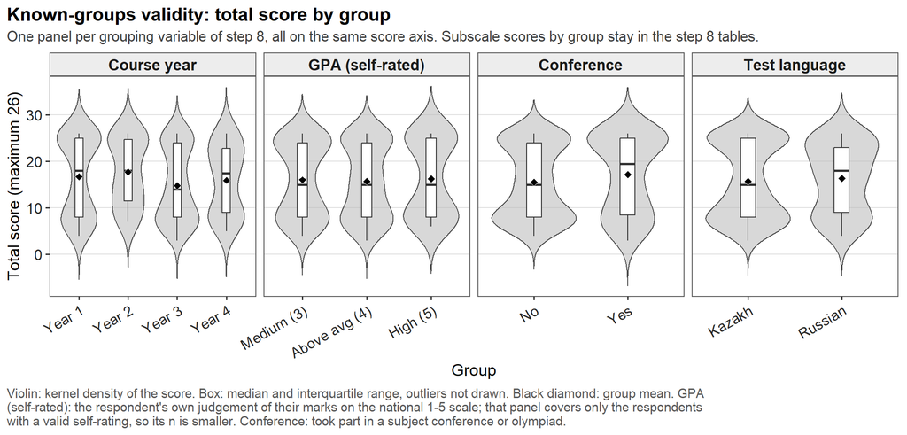

Общий балл по всем группирующим переменным шага 8: курс, GPA, конференции, язык

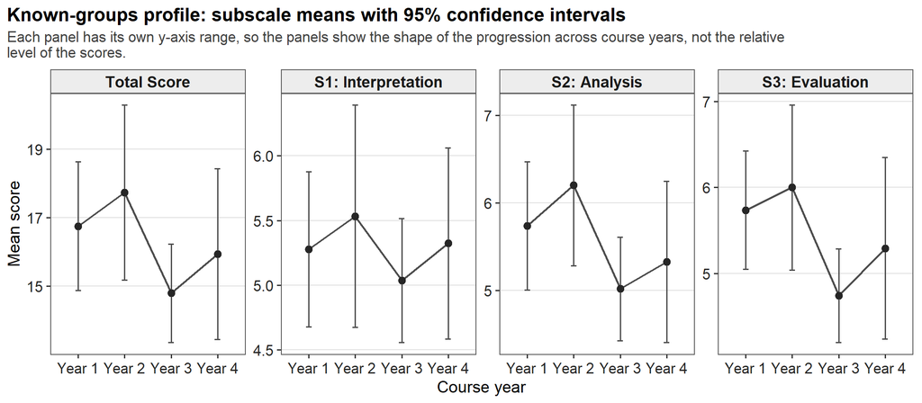

Профиль субшкал по курсам: средние с 95% ДИ

**Развёрнутые статистики ANOVA (Левен, Уэлч, Краскел-Уоллис, MANOVA, t-тесты, GPA, регион)**

```
====================================================================
  ANOVA — ВАЛИДНОСТЬ ПО ИЗВЕСТНЫМ ГРУППАМ | ТКМ-Хим
  n = 253 | Дата: 2026-09-15
====================================================================

  1. ОПИСАТЕЛЬНЫЕ СТАТИСТИКИ
====================================================================
  1.1 По курсам
# A tibble: 4 × 10
  Course     n Score_Total_M Score_Total_SD Score_S1_M Score_S1_SD Score_S2_M
  <fct>  <int>         <dbl>          <dbl>      <dbl>       <dbl>      <dbl>
1 1 курс    76          16.8           8.34       5.28        2.67       5.74
2 2 курс    30          17.7           7.12       5.53        2.4        6.2
3 3 курс   113          14.8           7.8        5.04        2.6        5.02
4 4 курс    34          15.9           7.4        5.32        2.2        5.32
# ℹ 3 more variables: Score_S2_SD <dbl>, Score_S3_M <dbl>, Score_S3_SD <dbl>

  1.2 По конференциям
# A tibble: 2 × 10
  Conference     n Score_Total_M Score_Total_SD Score_S1_M Score_S1_SD
  <fct>      <int>         <dbl>          <dbl>      <dbl>       <dbl>
1 Нет          195          15.5           7.73       5.09        2.55
2 Да            58          17.2           8.24       5.6         2.46
# ℹ 4 more variables: Score_S2_M <dbl>, Score_S2_SD <dbl>, Score_S3_M <dbl>,
#   Score_S3_SD <dbl>

  1.3 По языку
# A tibble: 2 × 10
  Language     n Score_Total_M Score_Total_SD Score_S1_M Score_S1_SD Score_S2_M
  <fct>    <int>         <dbl>          <dbl>      <dbl>       <dbl>      <dbl>
1 Қазақ      192          15.7           8.02       5.17        2.62       5.37
2 Русский     61          16.3           7.39       5.33        2.28       5.56
# ℹ 3 more variables: Score_S2_SD <dbl>, Score_S3_M <dbl>, Score_S3_SD <dbl>

  1.4 По регионам
# A tibble: 16 × 10
   Region       n Score_Total_M Score_Total_SD Score_S1_M Score_S1_SD Score_S2_M
   <chr>    <int>         <dbl>          <dbl>      <dbl>       <dbl>      <dbl>
 1 Алматы      50          17.6           7.13       5.82        2.26       6.14
 2 Абайска…    46          13.6           7.5        4.65        2.56       4.39
```

[output cut: 189 more lines]

```
13 Конференции (t Уэлча)    Score_S3 0.14353215  ns
14        Язык (t Уэлча) Score_Total 0.60035240  ns
15        Язык (t Уэлча)    Score_S1 0.64371185  ns
16        Язык (t Уэлча)    Score_S2 0.67493212  ns
17        Язык (t Уэлча)    Score_S3 0.58377828  ns
18     GPA (Welch ANOVA) Score_Total 0.90900000  ns
19     GPA (Welch ANOVA)    Score_S1 0.93800000  ns
20     GPA (Welch ANOVA)    Score_S2 0.98500000  ns
21     GPA (Welch ANOVA)    Score_S3 0.54500000  ns
22        Регион (ANOVA) Score_Total 0.16740000  ns
23        Регион (ANOVA)    Score_S1 0.30900000  ns
24        Регион (ANOVA)    Score_S2 0.11770000  ns
25        Регион (ANOVA)    Score_S3 0.33640000  ns

  Сравнений с p < 0.05: 0 из 25
```

# 13 Floor-страта: угадывание, пересчёт без пола, hub-кластер

Шаг 10. Отбор в страту идёт по сумме баллов, поэтому средняя по всем 26 пунктам доля верных внутри неё тождественно равна `M(балл)/k` и сверху ограничена `Floor_cut/k`: общий **уровень** доли внутри страты задан отбором, а не измерен. Измеряются распределение доли между пунктами и контраст hub-кластера (Q01, Q06, Q09, Q11, Q20, Q26) против остальных двадцати пунктов.

Внутри страты (n = 73, балл <= 8) средняя доля верных по всем пунктам равна `0.253` при уровне чистого угадывания `0.25` и структурном потолке `0.308`. Доля на hub-кластере — `0.409`, на остальных двадцати пунктах — `0.207`; разность внутри респондента `0.202`. Исход: **(b) превышение только на hub-пунктах** — альтернативный путь решения (методологический фактор).

Вердикт по floor-страте и границы отбора

| Metric | Value |
| --- | --- |
| Outcome | (b) превышение только на hub-пунктах |
| Reading | альтернативный путь решения (методологический фактор) |
| N_floor | 73 |
| Floor_cut | 8 |
| Mean_score_floor | 6.589 |
| Implied_mean_p | 0.253 |
| Structural_bound_p | 0.308 |
| P_guess | 0.25 |
| Hub_mean_p | 0.409 |
| Hub_p_holm | 1e-04 |
| Rest_mean_p | 0.207 |
| Rest_p_holm | 0.0018 |
| Hub_minus_rest | 0.202 |
| Hub_vs_rest_p | 1e-04 |
| Cochran_Q_p | 0 |
| N_items_above_guess | 3 |
| N_items_below_guess | 1 |

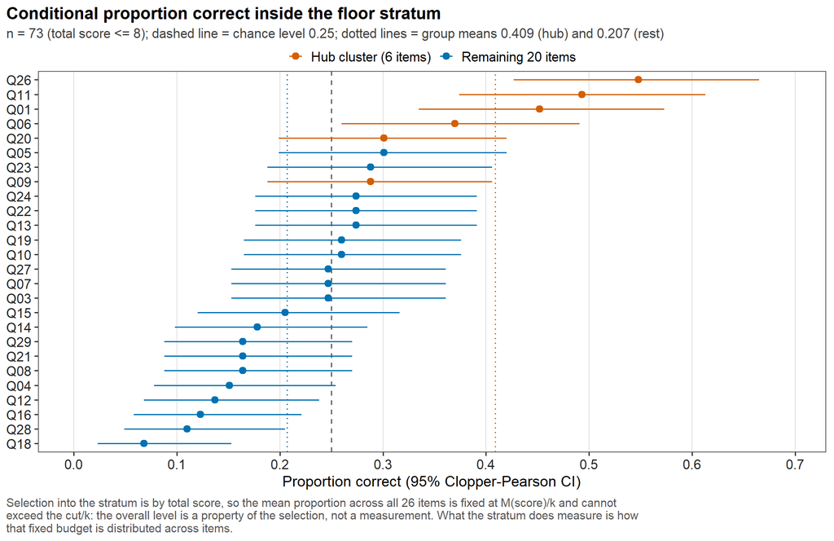

Условная доля верных по пунктам внутри floor-страты: точечная оценка с 95% ДИ против уровня угадывания

Доля верных по каждому пункту внутри floor-страты

| Item | Subscale | Group | N | Correct | P_correct | CI_low | CI_high | Chi2 | df | P_binom | P_holm | Above_guess | Below_guess |
| --- | --- | --- | --- | --- | --- | --- | --- | --- | --- | --- | --- | --- | --- |
| Q01 | S1 | hub | 73 | 33 | 0.452 | 0.335 | 0.573 | 15.895 | 1 | 0.0002 | 0.0045 | TRUE | FALSE |
| Q03 | S1 | rest | 73 | 18 | 0.247 | 0.153 | 0.361 | 0.005 | 1 | 1.0000 | 1.0000 | FALSE | FALSE |
| Q04 | S1 | rest | 73 | 11 | 0.151 | 0.078 | 0.254 | 3.840 | 1 | 0.0575 | 1.0000 | FALSE | FALSE |
| Q05 | S1 | rest | 73 | 22 | 0.301 | 0.199 | 0.420 | 1.027 | 1 | 0.3434 | 1.0000 | FALSE | FALSE |
| Q06 | S1 | hub | 73 | 27 | 0.370 | 0.260 | 0.491 | 5.594 | 1 | 0.0215 | 0.4302 | FALSE | FALSE |
| Q07 | S1 | rest | 73 | 18 | 0.247 | 0.153 | 0.361 | 0.005 | 1 | 1.0000 | 1.0000 | FALSE | FALSE |
| Q08 | S1 | rest | 73 | 12 | 0.164 | 0.088 | 0.270 | 2.854 | 1 | 0.1044 | 1.0000 | FALSE | FALSE |
| Q09 | S1 | hub | 73 | 21 | 0.288 | 0.188 | 0.406 | 0.553 | 1 | 0.4988 | 1.0000 | FALSE | FALSE |
| Q10 | S2 | rest | 73 | 19 | 0.260 | 0.165 | 0.376 | 0.041 | 1 | 0.8925 | 1.0000 | FALSE | FALSE |
| Q11 | S2 | hub | 73 | 36 | 0.493 | 0.374 | 0.613 | 23.018 | 1 | 0.0000 | 0.0002 | TRUE | FALSE |
| Q12 | S2 | rest | 73 | 10 | 0.137 | 0.068 | 0.238 | 4.973 | 1 | 0.0295 | 0.5601 | FALSE | FALSE |
| Q13 | S2 | rest | 73 | 20 | 0.274 | 0.176 | 0.391 | 0.224 | 1 | 0.6850 | 1.0000 | FALSE | FALSE |
| Q14 | S2 | rest | 73 | 13 | 0.178 | 0.098 | 0.285 | 2.014 | 1 | 0.1772 | 1.0000 | FALSE | FALSE |
| Q15 | S2 | rest | 73 | 15 | 0.205 | 0.120 | 0.316 | 0.772 | 1 | 0.4202 | 1.0000 | FALSE | FALSE |
| Q16 | S2 | rest | 73 | 9 | 0.123 | 0.058 | 0.221 | 6.251 | 1 | 0.0100 | 0.2108 | FALSE | FALSE |
| Q18 | S2 | rest | 73 | 5 | 0.068 | 0.023 | 0.153 | 12.826 | 1 | 0.0001 | 0.0027 | FALSE | TRUE |
| Q19 | S2 | rest | 73 | 19 | 0.260 | 0.165 | 0.376 | 0.041 | 1 | 0.8925 | 1.0000 | FALSE | FALSE |
| Q20 | S3 | hub | 73 | 22 | 0.301 | 0.199 | 0.420 | 1.027 | 1 | 0.3434 | 1.0000 | FALSE | FALSE |
| Q21 | S3 | rest | 73 | 12 | 0.164 | 0.088 | 0.270 | 2.854 | 1 | 0.1044 | 1.0000 | FALSE | FALSE |
| Q22 | S3 | rest | 73 | 20 | 0.274 | 0.176 | 0.391 | 0.224 | 1 | 0.6850 | 1.0000 | FALSE | FALSE |
| Q23 | S3 | rest | 73 | 21 | 0.288 | 0.188 | 0.406 | 0.553 | 1 | 0.4988 | 1.0000 | FALSE | FALSE |
| Q24 | S3 | rest | 73 | 20 | 0.274 | 0.176 | 0.391 | 0.224 | 1 | 0.6850 | 1.0000 | FALSE | FALSE |
| Q26 | S3 | hub | 73 | 40 | 0.548 | 0.427 | 0.665 | 34.562 | 1 | 0.0000 | 0.0000 | TRUE | FALSE |
| Q27 | S3 | rest | 73 | 18 | 0.247 | 0.153 | 0.361 | 0.005 | 1 | 1.0000 | 1.0000 | FALSE | FALSE |
| Q28 | S3 | rest | 73 | 8 | 0.110 | 0.049 | 0.205 | 7.676 | 1 | 0.0042 | 0.0924 | FALSE | FALSE |
| Q29 | S3 | rest | 73 | 12 | 0.164 | 0.088 | 0.270 | 2.854 | 1 | 0.1044 | 1.0000 | FALSE | FALSE |

Группы пунктов: hub-кластер против остальных

| Group | K_items | N_persons | Responses | Correct | P_pooled | CI_low | CI_high | P_binom_pooled | Mean_person_prop | SD_person_prop | t | df | P_person_t | V_wilcox | P_person_wilcox | P_person_holm |
| --- | --- | --- | --- | --- | --- | --- | --- | --- | --- | --- | --- | --- | --- | --- | --- | --- |
| hub | 6 | 73 | 438 | 179 | 0.409 | 0.362 | 0.456 | 0.0000 | 0.409 | 0.316 | 4.296 | 72 | 0.0001 | 1731.5 | 0.0352 | 0.0001 |
| rest | 20 | 73 | 1460 | 302 | 0.207 | 0.186 | 0.229 | 0.0001 | 0.207 | 0.113 | -3.250 | 72 | 0.0018 | 526.0 | 0.0038 | 0.0018 |
| all | 26 | 73 | 1898 | 481 | 0.253 | 0.234 | 0.274 | 0.7304 | 0.253 | 0.048 | 0.605 | 72 | 0.5468 | 1627.5 | 0.1206 | NA |

Контрасты внутри страты: Cochran Q, парный hub/остальные, chi2 2x2

| Test | Statistic | df | P_value | Effect |
| --- | --- | --- | --- | --- |
| Cochran Q (равенство долей по 26 пунктам) | 125.201 | 25 | 0e+00 | NA |
| Парный t (hub - остальные, внутри респондента) | 4.157 | 72 | 1e-04 | 0.202 |
| Парный Wilcoxon (hub - остальные) | 1890.500 | NA | 3e-03 | 0.083 |
| chi2 2x2 (hub против остальных, объединённые ответы) | 72.538 | 1 | 0e+00 | NA |

## 13.1 Пересчёт 2PL без floor-страты

Сходимость рефита 2PL без floor-страты

| Model | N | K_items | Converged | Zero_var_items |
| --- | --- | --- | --- | --- |
| 2PL NO-FLOOR | 180 | 26 | TRUE | NA |

Попунктные a и b на подвыборке без floor-страты

| Item | Subscale | Group | a | b | p_value | High_disc | Extreme_disc |
| --- | --- | --- | --- | --- | --- | --- | --- |
| Q01 | S1 | hub | 1.838 | -1.428 | 0.850 | TRUE | FALSE |
| Q03 | S1 | rest | 1.496 | -1.514 | 0.839 | TRUE | FALSE |
| Q04 | S1 | rest | 1.734 | -1.044 | 0.761 | TRUE | FALSE |
| Q05 | S1 | rest | 1.224 | -2.510 | 0.928 | FALSE | FALSE |
| Q06 | S1 | hub | 1.480 | -0.991 | 0.733 | TRUE | FALSE |
| Q07 | S1 | rest | 1.006 | -1.854 | 0.828 | FALSE | FALSE |
| Q08 | S1 | rest | 1.200 | -0.830 | 0.678 | FALSE | FALSE |
| Q09 | S1 | hub | 1.402 | -1.346 | 0.800 | TRUE | FALSE |
| Q10 | S2 | rest | 2.177 | -1.097 | 0.794 | TRUE | FALSE |
| Q11 | S2 | hub | 3.039 | -0.961 | 0.778 | TRUE | TRUE |
| Q12 | S2 | rest | 2.375 | -0.667 | 0.678 | TRUE | FALSE |
| Q13 | S2 | rest | 2.996 | -1.402 | 0.894 | TRUE | FALSE |
| Q14 | S2 | rest | 2.922 | -0.791 | 0.722 | TRUE | FALSE |
| Q15 | S2 | rest | 2.241 | -0.902 | 0.744 | TRUE | FALSE |
| Q16 | S2 | rest | 1.841 | -0.763 | 0.694 | TRUE | FALSE |
| Q18 | S2 | rest | 2.397 | -0.575 | 0.650 | TRUE | FALSE |
| Q19 | S2 | rest | 2.664 | -1.228 | 0.844 | TRUE | FALSE |
| Q20 | S3 | hub | 2.272 | -0.919 | 0.750 | TRUE | FALSE |
| Q21 | S3 | rest | 3.823 | -0.730 | 0.706 | TRUE | TRUE |
| Q22 | S3 | rest | 2.240 | -0.786 | 0.711 | TRUE | FALSE |
| Q23 | S3 | rest | 1.744 | -0.505 | 0.622 | TRUE | FALSE |
| Q24 | S3 | rest | 1.853 | -0.974 | 0.750 | TRUE | FALSE |
| Q26 | S3 | hub | 1.664 | -0.990 | 0.744 | TRUE | FALSE |
| Q27 | S3 | rest | 1.831 | -1.046 | 0.767 | TRUE | FALSE |
| Q28 | S3 | rest | 2.731 | -0.605 | 0.661 | TRUE | FALSE |
| Q29 | S3 | rest | 2.344 | -0.836 | 0.728 | TRUE | FALSE |

## 13.2 Person-fit, смесь с классом угадывания, hub-кластер как фактор

Person-fit по стратам: Zh (lz) и ошибки Гуттмана

| Stratum | N | Zh_mean | Zh_SD | N_misfit | Pct_misfit | Gstar_mean | Gstar_SD | N_Gstar_undefined |
| --- | --- | --- | --- | --- | --- | --- | --- | --- |
| floor | 73 | -0.021 | 0.630 | 1 | 1.4 | 0.363 | 0.158 | 0 |
| no-floor | 180 | 0.236 | 0.637 | 2 | 1.1 | 0.351 | 0.172 | 45 |
| all | 253 | 0.162 | 0.644 | 3 | 1.2 | 0.356 | 0.167 | 45 |

Смесь «чистое угадывание + 2PL»: доля класса случайных ответов

| Metric | Value |
| --- | --- |
| Pi_random | 0.2816 |
| N_posterior_gt_0.5 | 74 |
| Pct_posterior_gt_0.5 | 29.2 |
| logLik_mixture | -3112.53 |
| logLik_2PL_only | -3173.78 |
| AIC_mixture | 6331.06 |
| AIC_2PL_only | 6451.56 |
| BIC_mixture | 6518.33 |
| BIC_2PL_only | 6635.29 |
| EM_iterations | 25 |
| Converged | TRUE |

Тот же класс в разбивке по стратам

| Stratum | N | N_random | Pct_random | Mean_P_random |
| --- | --- | --- | --- | --- |
| floor | 73 | 55 | 75.3 | 0.711 |
| no-floor | 180 | 19 | 10.6 | 0.107 |
| all | 253 | 74 | 29.2 | 0.282 |

Сходимость бифакторной 2PL со специфическим фактором на hub-кластере

| Model | K_items | K_specific | Converged |
| --- | --- | --- | --- |
| Bifactor 2PL: G + S_hub | 26 | 6 | TRUE |

Индексы бифакторной 2PL с S_hub: omega_h, ECV, ECV_S_hub, PUC

| Index | Value |
| --- | --- |
| omega_h | 0.957 |
| omega_total | 0.979 |
| ECV | 0.911 |
| ECV_S_hub | 0.089 |
| PUC | 0.954 |
| omega_s_hub | 0.917 |
| omega_hs_hub | 0.358 |

**Нагрузки бифакторной 2PL с S_hub (52 строк)**

| Factor | Item | Beta |
| --- | --- | --- |
| G | Q01 | 0.668 |
| G | Q03 | 0.793 |
| G | Q04 | 0.804 |
| G | Q05 | 0.865 |
| G | Q06 | 0.571 |
| G | Q07 | 0.737 |
| G | Q08 | 0.699 |
| G | Q09 | 0.684 |
| G | Q10 | 0.824 |
| G | Q11 | 0.652 |
| G | Q12 | 0.842 |
| G | Q13 | 0.907 |
| G | Q14 | 0.851 |
| G | Q15 | 0.833 |
| G | Q16 | 0.808 |
| G | Q18 | 0.869 |
| G | Q19 | 0.891 |
| G | Q20 | 0.688 |
| G | Q21 | 0.882 |
| G | Q22 | 0.760 |
| G | Q23 | 0.670 |
| G | Q24 | 0.761 |
| G | Q26 | 0.490 |
| G | Q27 | 0.786 |
| G | Q28 | 0.848 |
| G | Q29 | 0.829 |
| S_hub | Q01 | 0.478 |
| S_hub | Q03 | 0.000 |
| S_hub | Q04 | 0.000 |
| S_hub | Q05 | 0.000 |
| S_hub | Q06 | 0.654 |
| S_hub | Q07 | 0.000 |
| S_hub | Q08 | 0.000 |
| S_hub | Q09 | 0.465 |
| S_hub | Q10 | 0.000 |
| S_hub | Q11 | 0.469 |
| S_hub | Q12 | 0.000 |
| S_hub | Q13 | 0.000 |
| S_hub | Q14 | 0.000 |
| S_hub | Q15 | 0.000 |
| S_hub | Q16 | 0.000 |
| S_hub | Q18 | 0.000 |
| S_hub | Q19 | 0.000 |
| S_hub | Q20 | 0.469 |
| S_hub | Q21 | 0.000 |
| S_hub | Q22 | 0.000 |
| S_hub | Q23 | 0.000 |
| S_hub | Q24 | 0.000 |
| S_hub | Q26 | 0.466 |
| S_hub | Q27 | 0.000 |
| S_hub | Q28 | 0.000 |
| S_hub | Q29 | 0.000 |

Структура и надёжность на 20 пунктах без hub-кластера

| K_items | N | alpha | alpha_ord | omega_t | omega_h | H | Smoothed | nfact_FA | ncomp_PCA | CFA_1F_cfi | CFA_1F_tli | CFA_1F_rmsea | CFA_1F_srmr | CFA_3F_cfi | CFA_3F_tli | CFA_3F_rmsea | CFA_3F_srmr |
| --- | --- | --- | --- | --- | --- | --- | --- | --- | --- | --- | --- | --- | --- | --- | --- | --- | --- |
| 20 | 253 | 0.935 | 0.97 | 0.976 | 0.848 | 0.496 | TRUE | 2 | 1 | 0.994 | 0.993 | 0.031 | 0.059 | 1 | 1 | 0 | 0.048 |

**Собственные значения 20 пунктов против линии параллельного анализа (20 строк)**

| Factor | Eigenvalue | PA_line |
| --- | --- | --- |
| 1 | 9.013 | 1.516 |
| 2 | 1.172 | 1.438 |
| 3 | 0.935 | 1.376 |
| 4 | 0.849 | 1.311 |
| 5 | 0.769 | 1.236 |
| 6 | 0.690 | 1.181 |
| 7 | 0.664 | 1.142 |
| 8 | 0.634 | 1.096 |
| 9 | 0.606 | 1.051 |
| 10 | 0.585 | 1.008 |
| 11 | 0.573 | 0.955 |
| 12 | 0.528 | 0.912 |
| 13 | 0.472 | 0.873 |
| 14 | 0.452 | 0.843 |
| 15 | 0.420 | 0.785 |
| 16 | 0.403 | 0.744 |
| 17 | 0.370 | 0.706 |
| 18 | 0.342 | 0.659 |
| 19 | 0.315 | 0.613 |
| 20 | 0.208 | 0.556 |

**Развёрнутые статистики**

```
========================================================================
  FLOOR-СТРАТА -- N = 253, пунктов: 26, граница пола: <= 8
========================================================================

------------------------------------------------------------------------
  1. УСЛОВНАЯ ДОЛЯ ВЕРНЫХ ВНУТРИ FLOOR-СТРАТЫ
------------------------------------------------------------------------
  n = 73 (28.9% выборки), M(балл) = 6.59, SD = 1.26
  Уровень чистого угадывания: 0.25 (4 варианта на пункт)
  Средняя по 26 пунктам доля верных = M(балл)/k = 0.253;
  её ПОТОЛОК внутри страты задан отбором: 8/26 = 0.308.
  Отсюда: общий уровень доли внутри страты -- свойство отбора, а не измерение,
  и исход «равномерно повышенные доли на всех 26» внутри неё ненаблюдаем.
  Измеряются РАСПРЕДЕЛЕНИЕ доли между пунктами и КОНТРАСТ hub/остальные.

  Item   Sub  Grp    Correct       p          95% CI  p(binom)   p(Holm)
  --------------------------------------------------------------------
  Q01    S1   hub         33   0.452  [0.335; 0.573]    0.0002    0.0045  ^
  Q03    S1   rest        18   0.247  [0.153; 0.361]    1.0000    1.0000
  Q04    S1   rest        11   0.151  [0.078; 0.254]    0.0575    1.0000
  Q05    S1   rest        22   0.301  [0.199; 0.420]    0.3434    1.0000
  Q06    S1   hub         27   0.370  [0.260; 0.491]    0.0215    0.4302
  Q07    S1   rest        18   0.247  [0.153; 0.361]    1.0000    1.0000
  Q08    S1   rest        12   0.164  [0.088; 0.270]    0.1044    1.0000
  Q09    S1   hub         21   0.288  [0.188; 0.406]    0.4988    1.0000
  Q10    S2   rest        19   0.260  [0.165; 0.376]    0.8925    1.0000
  Q11    S2   hub         36   0.493  [0.374; 0.613]    0.0000    0.0002  ^
  Q12    S2   rest        10   0.137  [0.068; 0.238]    0.0295    0.5601
  Q13    S2   rest        20   0.274  [0.176; 0.391]    0.6850    1.0000
  Q14    S2   rest        13   0.178  [0.098; 0.285]    0.1772    1.0000
  Q15    S2   rest        15   0.205  [0.120; 0.316]    0.4202    1.0000
  Q16    S2   rest         9   0.123  [0.058; 0.221]    0.0100    0.2108
  Q18    S2   rest         5   0.068  [0.023; 0.153]    0.0001    0.0027  v
  Q19    S2   rest        19   0.260  [0.165; 0.376]    0.8925    1.0000
  Q20    S3   hub         22   0.301  [0.199; 0.420]    0.3434    1.0000
  Q21    S3   rest        12   0.164  [0.088; 0.270]    0.1044    1.0000
  Q22    S3   rest        20   0.274  [0.176; 0.391]    0.6850    1.0000
  Q23    S3   rest        21   0.288  [0.188; 0.406]    0.4988    1.0000
  Q24    S3   rest        20   0.274  [0.176; 0.391]    0.6850    1.0000
  Q26    S3   hub         40   0.548  [0.427; 0.665]    0.0000    0.0000  ^
```

[output cut: 154 more lines]

```
      20 253 0.935      0.97   0.976   0.848 0.496     TRUE        2         1
 CFA_1F_cfi CFA_1F_tli CFA_1F_rmsea CFA_1F_srmr CFA_3F_cfi CFA_3F_tli
      0.994      0.993        0.031       0.059          1          1
 CFA_3F_rmsea CFA_3F_srmr
            0       0.048

  Собственные значения корреляционной матрицы против линии параллельного анализа:

 Factor Eigenvalue PA_line
      1      9.013   1.516
      2      1.172   1.438
      3      0.935   1.376
      4      0.849   1.311
      5      0.769   1.236
      6      0.690   1.181
```